# Purpose

The purpose of this project is to leverage data analysis and machine learning to uncover actionable insights from Airbnb property listings. By analyzing trends in pricing, customer preferences, and property performance, the project aims to support hosts in making data-driven decisions to optimize their revenue, improve guest satisfaction, and enhance booking rates.

# Scope

The scope of this project encompasses:

1.Data Analysis: Examining Airbnb property data to identify key factors influencing pricing, availability, customer satisfaction, and booking trends.

2.Machine Learning Models: Developing predictive models for pricing, property availability, and customer satisfaction to aid strategic decision-making.

3.Trend Analysis: Studying seasonal and regional variations in booking frequencies and guest behavior.

4.Recommendations: Generating insights and strategies that Airbnb hosts can implement to improve performance and attract more bookings.

# Objectives

To identify patterns and trends in property pricing based on location, amenities, and host attributes.

To analyze customer reviews and ratings to understand the drivers of guest satisfaction.

To uncover trends in property availability and booking frequency across different time periods.

To develop predictive models for:

```
Pricing: Determining optimal property pricing strategies.

Availability: Forecasting property booking likelihood.

Customer Satisfaction: Predicting guest ratings and sentiment.
```

To provide actionable insights and recommendations for hosts to improve property performance and attract more bookings.

# Problems Aim to Solve

The aim of this project is to solve key challenges faced by Airbnb hosts and the platform itself by addressing the following problems:

Optimizing Pricing Strategies: Identifying factors that influence property prices and providing insights to set competitive and attractive pricing.

Improving Customer Satisfaction: Understanding what drives positive reviews and ratings to help hosts enhance guest experiences.

Forecasting Property Availability: Predicting booking trends and availability to help hosts and guests plan better.

Identifying Booking Behaviors: Analyzing trends to uncover why certain listings outperform others and how hosts can adapt to increase bookings.

Providing Data-Driven Recommendations: Offering actionable strategies to maximize revenues and improve the overall performance of Airbnb listings.

This project ultimately aims to support data-driven decision-making for hosts and improve the platform's value for both hosts and guests.

# Importance and Relevance

## Importance

Enhancing Host Success: By identifying factors that influence pricing and customer satisfaction, the project provides hosts with actionable insights to optimize their performance and revenue.

Improving Guest Experience: Analyzing reviews and preferences helps in understanding guest needs, enabling hosts to provide better accommodations and services.

Market Trends Understanding: This project sheds light on booking patterns and trends, helping hosts adapt to seasonal demands and changing customer behaviors.

Data-Driven Decision Making: It equips stakeholders with analytical tools and predictive models, reducing reliance on guesswork and enabling smarter strategies.

## Relevance

Competitive Edge in a Growing Industry: As Airbnb continues to expand, hosts face increased competition. Understanding market dynamics through data analysis is essential for staying ahead.

Adapting to Guest Expectations: The project highlights evolving guest preferences and expectations, allowing hosts to stay relevant and cater to modern traveler needs.

Empowering Hosts: By providing insights into key performance indicators like pricing, availability, and reviews, hosts can make informed decisions to maximize their potential.

Scalability: The project's methodologies and findings could be applied not only to individual hosts but also to regional or even global analyses of the Airbnb market.

# Summary

The Approach to Achieving the Objectives of the Airbnb Data Analysis Project Involves: Data Collection and Integration: Collecting and integrating data on property listings, customer reviews, host details, pricing, and booking information from Airbnb datasets.

Data Processing and Storage: Cleaning, preprocessing, and securely storing the data in a structured format for seamless analysis.

Data Interpretation and Visualization: Developing algorithms and visualizations to identify key insights, such as pricing trends, guest preferences, and booking patterns.

Pricing Trends Analysis: Analyzing pricing trends to understand the impact of property features, location, and host behavior on pricing strategies.

Review Sentiment Analysis: Extracting and analyzing reviews to uncover drivers of customer satisfaction and dissatisfaction, using sentiment analysis techniques.

Booking Behavior Analysis: Identifying trends in property availability and booking frequency across different time periods and locations.

Predictive Modeling: Building machine learning models to predict:

Optimal Pricing based on property and host attributes.

Booking Likelihood for properties.

Customer Satisfaction based on amenities and service quality.

Actionable Insights: Providing strategic recommendations for hosts to improve property performance, attract more bookings, and enhance guest experiences.

Continuous Improvement: Refining models and analyses with new data to ensure accuracy and relevance over time.

Privacy and Security: Ensuring the security of property and user data with robust privacy measures, adhering to regulations and ethical guidelines.

## Import Libraries

```python
import pandas as pd
import numpy as np
import matplotlib.pyplot as plt
import seaborn as sns
import warnings
from scipy.stats import zscore
import warnings
import matplotlib.image as mpimg
%matplotlib inline
from sklearn.cluster import KMeans
from textblob import TextBlob
from datetime import datetime
from sklearn.preprocessing import StandardScaler
from sklearn.preprocessing import MinMaxScaler
from sklearn.preprocessing import RobustScaler
from sklearn.preprocessing import Normalizer
from sklearn.pipeline import Pipeline
from sklearn.ensemble import RandomForestClassifier
from sklearn.pipeline import Pipeline
from sklearn.ensemble import RandomForestRegressor  # For regression, suitable for price prediction
from sklearn.preprocessing import StandardScaler
from sklearn.model_selection import train_test_split
from sklearn.ensemble import GradientBoostingRegressor
from sklearn.metrics import mean_squared_error, mean_absolute_error
from sklearn.metrics import mean_squared_error, r2_score
from sklearn.preprocessing import LabelEncoder
import joblib
from sklearn.metrics import classification_report, accuracy_score, confusion_matrix
from vaderSentiment.vaderSentiment import SentimentIntensityAnalyzer
from sklearn.feature_extraction.text import TfidfVectorizer
import re
from nltk.corpus import stopwords
from nltk.stem import WordNetLemmatizer
import nltk
from sklearn.feature_extraction.text import CountVectorizer
nltk.download('stopwords')
nltk.download('wordnet')
```

```
True
```

Code Explanation: These libraries are essential for handling data (Pandas, NumPy), creating visualizations (Matplotlib, Seaborn), and building and evaluating machine learning models (Scikit-learn).

Why it's Important :This setup is important because it provides the foundation for executing a comprehensive data analysis project. Each library and tool serves a specific purpose in handling, analyzing, or interpreting complex data.

# 1. Understand the Dataset

## Examine dataset structure, column types, and data distributions.

### Load Dataset

```python
df = pd.read_csv('airbnb.csv')

print(df.head())
```

```
   Unnamed: 0  listing_id                                               name  \
0         0.0  13740704.0  cozy,budget friendly, cable inc, private entra...
1         1.0  22005115.0              two floor apartment near central park
2         2.0  21667615.0                  beautiful 1br in brooklyn heights
3         3.0   6425850.0                          spacious, charming studio
4         4.0  22986519.0              bedroom on the lively lower east side

       host_id host_name          neighbourhood_full            coordinates  \
0   20583125.0    michel         brooklyn, flatlands  (40.63222, -73.93398)
1   82746113.0   cecilia  manhattan, upper west side  (40.78761, -73.96862)
2      78251.0    leslie  brooklyn, brooklyn heights   (40.7007, -73.99517)
3   32715865.0    yelena  manhattan, upper west side  (40.79169, -73.97498)
4  154262349.0    brooke  manhattan, lower east side  (40.71884, -73.98354)

         room_type  price  number_of_reviews last_review  reviews_per_month  \
```

[output cut: 26 more lines]

Code Explanation: :The dataset is loaded into a DataFrame, and the first few rows are displayed understand the structure and content of the data.This command displays the first 5 rows of the DataFrame (df) by default.

Why its Important: Loading the data allows us to inspect the first few rows and understand its structure and contents.it offers a quick glimpse into the structure and contents of your dataset, ensuring that the data has been loaded accurately.

```python
print(df.shape)
print(df.info())
```

```
(10017, 20)
<class 'pandas.core.frame.DataFrame'>
RangeIndex: 10017 entries, 0 to 10016
Data columns (total 20 columns):
 #   Column                Non-Null Count  Dtype
---  ------                --------------  -----
 0   Unnamed: 0            10017 non-null  float64
 1   listing_id            10017 non-null  float64
 2   name                  10017 non-null  object
 3   host_id               10017 non-null  float64
 4   host_name             10017 non-null  object
 5   neighbourhood_full    10017 non-null  object
 6   coordinates           10017 non-null  object
 7   room_type             10017 non-null  object
 8   price                 10017 non-null  float64
 9   number_of_reviews     10017 non-null  float64
 10  last_review           10017 non-null  object
 11  reviews_per_month     10017 non-null  float64
 12  availability_365      10017 non-null  float64
 13  rating                10017 non-null  float64
 14  number_of_stays       10017 non-null  float64
 15  5_stars               10017 non-null  float64
 16  listing_added         10017 non-null  object
 17  borough               10017 non-null  object
 18  neighborhood_cluster  10017 non-null  int64
 19  reviews               10017 non-null  object
dtypes: float64(10), int64(1), object(9)
memory usage: 1.5+ MB
None
```

Code Explanation: This command outputs the dimensions of the DataFrame df. The result is a tuple in the format (rows, columns).his command provides a summary of the DataFrame.

```python
print(df.describe(include='all'))
```

```
          Unnamed: 0    listing_id                           name  \
count   10017.000000  1.001700e+04                          10017
unique           NaN           NaN                           9880
top              NaN           NaN  beautiful brooklyn brownstone
freq             NaN           NaN                             10
mean     5008.686932  1.927623e+07                            NaN
std      2892.455554  1.095164e+07                            NaN
min         0.000000  3.831000e+03                            NaN
25%      2504.000000  9.670233e+06                            NaN
50%      5009.000000  2.007030e+07                            NaN
75%      7513.000000  2.933872e+07                            NaN
max     10018.000000  3.648724e+07                            NaN

             host_id host_name            neighbourhood_full  \
count   1.001700e+04     10017                         10017
unique           NaN      4077                           198
top              NaN   michael  brooklyn, bedford-stuyvesant
freq             NaN        91                           776
mean    6.772783e+07       NaN                           NaN
std     7.803259e+07       NaN                           NaN
min     2.787000e+03       NaN                           NaN
25%     7.910657e+06       NaN                           NaN
50%     3.165872e+07       NaN                           NaN
75%     1.074344e+08       NaN                           NaN
max     2.567197e+08       NaN                           NaN

                  coordinates        room_type         price  \
count                   10017            10017  10017.000000
unique                   9995                3           NaN
top     (40.73652, -73.95236)  entire home/apt           NaN
freq                        2             5185           NaN
mean                      NaN              NaN    133.460916
std                       NaN              NaN     82.104786
min                       NaN              NaN     10.000000
25%                       NaN              NaN     70.000000
50%                       NaN              NaN    110.000000
75%                       NaN              NaN    175.000000
max                       NaN              NaN    332.500000

        number_of_reviews last_review  reviews_per_month  availability_365  \
```

[output cut: 35 more lines]

```
75%                 3.000000
max                 4.000000

                                                  reviews
count                                               10017
unique                                                295
top     This listing is good, with rarely reviewed fee...
freq                                                 2087
mean                                                  NaN
std                                                   NaN
min                                                   NaN
25%                                                   NaN
50%                                                   NaN
75%                                                   NaN
max                                                   NaN
```

Code Explanation: It provides summary statistics for all columns in a pandas dataframe, including numerical and non-numerical ones.

Why its Important: The importance of df.describe(include='all') lies in its ability to quickly provide detailed insights into all types of data in a pandas dataframe—both numerical and non-numerical.

### Identify missing values, outliers, and inconsistencies

```python
print(df.isnull().sum())
```

```
Unnamed: 0              0
listing_id              0
name                    0
host_id                 0
host_name               0
neighbourhood_full      0
coordinates             0
room_type               0
price                   0
number_of_reviews       0
last_review             0
reviews_per_month       0
availability_365        0
rating                  0
number_of_stays         0
5_stars                 0
listing_added           0
borough                 0
neighborhood_cluster    0
reviews                 0
dtype: int64
```

Code Explanation: The code print(df.isnull().sum()) is used in Python with pandas to detect missing values in a dataframe.

Why its Important: The command print(df.isnull().sum()) is crucial for detecting missing data in a pandas dataframe

```python
numeric_columns = df.select_dtypes(include=[np.number]).columns

outliers_dict = {}

for column in numeric_columns:
    Q1 = df[column].quantile(0.25)
    Q3 = df[column].quantile(0.75)
    IQR = Q3 - Q1
    lower_bound = Q1 - 1.5 * IQR
    upper_bound = Q3 + 1.5 * IQR
    outliers = df[(df[column] < lower_bound) | (df[column] > upper_bound)]
    if not outliers.empty:
        outliers_dict[column] = outliers[column]
        (f"\nOutliers detected in column '{column}' using IQR method:")
        (outliers)

print("\nSummary: Columns with outliers")
for column, outliers in outliers_dict.items():
    print(f"{column}: {len(outliers)} outliers found")
```

```
Summary: Columns with outliers
number_of_stays: 1047 outliers found
5_stars: 574 outliers found
```

Code Explanation: This code detects outliers in numerical columns of a dataframe (df) using the IQR (Interquartile Range) method. It selects numeric columns, calculates the IQR (Q3 - Q1), defines lower and upper bounds, and identifies rows with values outside these bounds as outliers.

Why its important: Detecting outliers using the IQR method ensures data quality by identifying anomalies that could skew results or indicate significant deviations, helping to clean data, improve model performance, and support accurate decision-making.

```python
# Suppress specific warnings
warnings.filterwarnings('ignore', message="Glyph .* missing from font")

# Initialize dictionaries to store inconsistencies
summary_inconsistencies = {}

# Detect inconsistent categories in categorical data
categorical_columns = df.select_dtypes(include='object').columns
categorical_summary = {}
for column in categorical_columns:
    value_counts = df[column].value_counts()
    categorical_summary[column] = value_counts

# Store the categorical summary in inconsistencies
summary_inconsistencies['Categorical Issues'] = categorical_summary

# Print Summary of Inconsistencies
print("\nSummary of Inconsistencies:")
for key, value in summary_inconsistencies.items():
    print(f"{key}: {value}")
```

```
Summary of Inconsistencies:
Categorical Issues: {'name': name
beautiful brooklyn brownstone                       10
home away from home                                 10
private room                                         5
new york multi-unit building                         5
cozy private room                                    4
                                                    ..
beautiful garden rooms in lower east side            1
ideal bushwick, 2 bdrm, basement, private garden     1
gorgeous large room near lga                         1
sun-soaked, charming brooklyn home                   1
two floor apartment near central park                1
Name: count, Length: 9880, dtype: int64, 'host_name': host_name
michael         91
david           85
sonder (nyc)    66
alex            52
daniel          50
                ..
rhian            1
crispy           1
gail             1
sagar            1
dovber           1
Name: count, Length: 4077, dtype: int64, 'neighbourhood_full': neighbourhood_full
brooklyn, bedford-stuyvesant      776
brooklyn, williamsburg            766
manhattan, harlem                 541
brooklyn, bushwick                502
manhattan, hell's kitchen         405
                                 ...
brooklyn, bath beach                1
staten island, great kills          1
staten island, midland beach        1
bronx, eastchester                  1
staten island, new springville      1
Name: count, Length: 198, dtype: int64, 'coordinates': coordinates
(40.73652, -73.95236)             2
(40.7235, -73.97963)              2
```

[output cut: 41 more lines]

```
bronx             229
staten island      73
Name: count, dtype: int64, 'reviews': reviews
This listing is good, with rarely reviewed feedback. It receives about 1.4 reviews per month.           2087
This listing is good, with rarely reviewed feedback. It receives about 0.1 reviews per month.            600
This listing is good, with rarely reviewed feedback. It receives about 0.2 reviews per month.            301
This listing is amazing, with rarely reviewed feedback. It receives about 0.1 reviews per month.         295
This listing is average, with rarely reviewed feedback. It receives about 0.1 reviews per month.         280
                                                                                                        ...
This listing is amazing, with highly reviewed feedback. It receives about 0.6 reviews per month.           2
This listing is average, with moderately reviewed feedback. It receives about 0.1 reviews per month.       2
This listing is amazing, with rarely reviewed feedback. It receives about 3.3 reviews per month.           1
This listing is amazing, with highly reviewed feedback. It receives about 2.6 reviews per month.           1
This listing is average, with highly reviewed feedback. It receives about 0.5 reviews per month.           1
Name: count, Length: 295, dtype: int64}
```

Code Explanation: This code detects inconsistencies in categorical columns by counting unique values for each column in a dataframe, storing the summaries in a dictionary, and printing a detailed report of the inconsistencies to help identify data quality issues.

Why its important: Detecting inconsistencies in categorical data is important because it ensures data integrity by identifying errors like misspellings, inconsistent formatting, or unexpected values. This improves the reliability of analysis, enhances data quality, and prevents misleading results in downstream processes such as modeling or reporting. It's a vital step in maintaining accurate and clean datasets.

# Data Cleaning

## Handle missing or inconsistent data with appropriate techniques

```python
numeric_columns = df.select_dtypes(include=np.number).columns
for column in numeric_columns:
    if df[column].isnull().sum() > 0:
        mean_value = df[column].mean()
        # Assign directly instead of using inplace=True
        df[column] = df[column].fillna(mean_value)

categorical_columns = df.select_dtypes(include='object').columns
for column in categorical_columns:
    if df[column].isnull().sum() > 0:
        most_frequent_value = df[column].mode()[0]
        # Assign directly instead of using inplace=True
        df[column] = df[column].fillna(most_frequent_value)

print("AFTER Imputation:")
print("Missing values in each column:")
print(df.isnull().sum())
```

```
AFTER Imputation:
Missing values in each column:
Unnamed: 0              0
listing_id              0
name                    0
host_id                 0
host_name               0
neighbourhood_full      0
coordinates             0
room_type               0
price                   0
number_of_reviews       0
last_review             0
reviews_per_month       0
availability_365        0
rating                  0
number_of_stays         0
5_stars                 0
listing_added           0
borough                 0
neighborhood_cluster    0
reviews                 0
dtype: int64
```

Code Explanation: This code imputes missing values in a dataframe by filling numeric columns with their mean and categorical columns with their most frequent value (mode). After the imputation, it prints a summary of missing values to confirm all have been handled.

Why its Important: Handling missing values is crucial because it ensures the dataset is complete and ready for analysis. Missing values can lead to biased results or errors in modeling. By imputing numeric columns with their mean and categorical columns with their mode, this code preserves data integrity, reduces potential distortions, and enables accurate predictions in downstream processes.

```python
for column in numeric_columns:
    if df[column].isnull().sum() > 0:
        df[column] = df[column].fillna(df[column].mean())

for column in categorical_columns:
    if df[column].isnull().sum() > 0:
        df[column] = df[column].fillna(df[column].mode()[0])

df = df.drop_duplicates()

for column in numeric_columns:
    Q1 = df[column].quantile(0.25)
    Q3 = df[column].quantile(0.75)
    IQR = Q3 - Q1
    lower_bound = Q1 - 1.5 * IQR
    upper_bound = Q3 + 1.5 * IQR
    df[column] = np.where(df[column] < lower_bound, lower_bound, df[column])
    df[column] = np.where(df[column] > upper_bound, upper_bound, df[column])

df['price'] = df['price'].replace(r'[\$,]', '', regex=True).astype(float)

if 'neighbourhood' in df.columns:  # Example for standardizing a column
    df['neighbourhood'] = df['neighbourhood'].str.lower().str.strip()

print("Cleaned Dataset Summary:")
print(df.info())
```

```
Cleaned Dataset Summary:
<class 'pandas.core.frame.DataFrame'>
RangeIndex: 10017 entries, 0 to 10016
Data columns (total 20 columns):
 #   Column                Non-Null Count  Dtype
---  ------                --------------  -----
 0   Unnamed: 0            10017 non-null  float64
 1   listing_id            10017 non-null  float64
 2   name                  10017 non-null  object
 3   host_id               10017 non-null  float64
 4   host_name             10017 non-null  object
 5   neighbourhood_full    10017 non-null  object
 6   coordinates           10017 non-null  object
 7   room_type             10017 non-null  object
 8   price                 10017 non-null  float64
 9   number_of_reviews     10017 non-null  float64
 10  last_review           10017 non-null  object
 11  reviews_per_month     10017 non-null  float64
 12  availability_365      10017 non-null  float64
 13  rating                10017 non-null  float64
 14  number_of_stays       10017 non-null  float64
 15  5_stars               10017 non-null  float64
 16  listing_added         10017 non-null  object
 17  borough               10017 non-null  object
 18  neighborhood_cluster  10017 non-null  float64
 19  reviews               10017 non-null  object
dtypes: float64(11), object(9)
memory usage: 1.5+ MB
None
```

Code Explanation: This code cleans a dataframe by handling missing values (numeric columns with mean, categorical with mode), removing duplicates, capping outliers using the IQR method, correcting data types (e.g., price column to float), and standardizing categorical values for consistency, ensuring the dataset is ready for analysis.

Why its Important: This process is important because it ensures the dataset is clean, consistent, and ready for analysis or modeling by addressing key issues like missing values, duplicates, outliers, and formatting errors, leading to more accurate and reliable results.

```python
categorical_columns = df.select_dtypes(include='object').columns
for column in categorical_columns:
    unique_values = df[column].unique()
    print(f"\nUnique values in categorical column '{column}': {unique_values}")
```

```
Unique values in categorical column 'name': ['cozy,budget friendly, cable inc, private entrance!'
 'two floor apartment near central park'
 'beautiful 1br in brooklyn heights' ...
 'artsy, garden getaway in central brooklyn'
 'immaculate townhouse in clinton hill, brooklyn'
 'private room in a perfect location in the city']

Unique values in categorical column 'host_name': ['michel' 'cecilia' 'leslie' ... 'shir' 'rahul' 'darktalia']

Unique values in categorical column 'neighbourhood_full': ['brooklyn, flatlands' 'manhattan, upper west side'
 'brooklyn, brooklyn heights' 'manhattan, lower east side'
 'manhattan, greenwich village' 'manhattan, harlem'
 'brooklyn, sheepshead bay' 'manhattan, theater district'
 'brooklyn, bushwick' 'queens, laurelton' 'bronx, mott haven'
 'queens, flushing' 'brooklyn, crown heights' 'manhattan, midtown'
 'manhattan, financial district' 'manhattan, east village'
 'brooklyn, park slope' 'manhattan, washington heights'
 'brooklyn, williamsburg' 'manhattan, chelsea'
 'brooklyn, bedford-stuyvesant' 'brooklyn, gowanus'
 'manhattan, upper east side' 'queens, ditmars steinway'
 'brooklyn, cypress hills' "manhattan, hell's kitchen" 'queens, ridgewood'
 'manhattan, marble hill' 'manhattan, kips bay'
 'brooklyn, prospect heights' 'brooklyn, east new york'
 'staten island, concord' 'staten island, stapleton' 'queens, astoria'
 'manhattan, east harlem' 'queens, sunnyside' 'manhattan, gramercy'
 'brooklyn, prospect-lefferts gardens' 'brooklyn, sunset park'
 'queens, forest hills' 'brooklyn, windsor terrace'
 'brooklyn, clinton hill' 'manhattan, murray hill'
 'manhattan, flatiron district' 'brooklyn, greenpoint'
 'brooklyn, east flatbush' 'manhattan, tribeca' 'queens, woodhaven'
 'brooklyn, fort greene' 'manhattan, inwood' 'manhattan, chinatown'
 'queens, rockaway beach' 'queens, woodside' 'queens, bayside'
 'brooklyn, bensonhurst' 'manhattan, soho' 'brooklyn, red hook'
 'manhattan, west village' 'brooklyn, south slope' 'queens, richmond hill'
 'queens, jamaica' 'brooklyn, boerum hill' 'staten island, st. george'
 'bronx, clason point' 'queens, college point' 'brooklyn, vinegar hill'
 'queens, rego park' 'queens, east elmhurst' 'brooklyn, kensington'
 'manhattan, roosevelt island' 'queens, ozone park' 'queens, arverne'
 'bronx, fordham' 'bronx, wakefield' 'bronx, port morris'
 'brooklyn, flatbush' 'queens, elmhurst' 'brooklyn, bay ridge'
```

[output cut: 340 more lines]

```
 'This listing is amazing, with rarely reviewed feedback. It receives about 1.3 reviews per month.'
 'This listing is average, with moderately reviewed feedback. It receives about 3.3 reviews per month.'
 'This listing is amazing, with rarely reviewed feedback. It receives about 3.3 reviews per month.'
 'This listing is average, with moderately reviewed feedback. It receives about 2.4 reviews per month.'
 'This listing is amazing, with rarely reviewed feedback. It receives about 2.4 reviews per month.'
 'This listing is amazing, with highly reviewed feedback. It receives about 3.1 reviews per month.'
 'This listing is amazing, with rarely reviewed feedback. It receives about 2.6 reviews per month.'
 'This listing is amazing, with moderately reviewed feedback. It receives about 2.7 reviews per month.'
 'This listing is amazing, with highly reviewed feedback. It receives about 0.6 reviews per month.'
 'This listing is average, with highly reviewed feedback. It receives about 1.4 reviews per month.'
 'This listing is average, with rarely reviewed feedback. It receives about 2.1 reviews per month.'
 'This listing is average, with highly reviewed feedback. It receives about 0.5 reviews per month.'
 'This listing is good, with rarely reviewed feedback. It receives about 2.7 reviews per month.'
 'This listing is average, with moderately reviewed feedback. It receives about 0.1 reviews per month.'
 'This listing is amazing, with rarely reviewed feedback. It receives about 2.9 reviews per month.']
```

Code Explanation: This code identifies categorical columns in a dataframe (df), retrieves unique values for each column using .unique(), and prints them to help understand the distinct categories present in the data.

Why its Importance: It helps detect inconsistencies, unexpected values, or patterns in categorical data, ensuring data integrity and guiding preprocessing tasks for accurate analysis.

```python
numeric_columns = df.select_dtypes(include=[np.number]).columns
for column in numeric_columns:
    Q1 = df[column].quantile(0.25)
    Q3 = df[column].quantile(0.75)
    IQR = Q3 - Q1
    lower_bound = Q1 - 1.5 * IQR
    upper_bound = Q3 + 1.5 * IQR
    outliers = df[(df[column] < lower_bound) | (df[column] > upper_bound)]
    if outliers.empty:
        print(f"\nNo outliers found in column '{column}'.")
    else:
        print(f"\nOutliers detected in column '{column}':")
        print(outliers)
```

```
No outliers found in column 'Unnamed: 0'.

No outliers found in column 'listing_id'.

No outliers found in column 'host_id'.

No outliers found in column 'price'.

No outliers found in column 'number_of_reviews'.

No outliers found in column 'reviews_per_month'.

No outliers found in column 'availability_365'.

No outliers found in column 'rating'.

No outliers found in column 'number_of_stays'.

No outliers found in column '5_stars'.

No outliers found in column 'neighborhood_cluster'.
```

Code Explanation: This code identifies outliers in numeric columns of a dataframe using the IQR method by calculating lower and upper bounds. It checks for values outside these bounds and prints either the detected outliers or a message indicating no outliers were found for each column.

Importance: Detecting outliers ensures data accuracy by identifying extreme values that could distort analysis or model predictions, making it an essential step in preprocessing and data quality improvement.

```python
# Calculate IQR for the 'price' column
Q1 = df['price'].quantile(0.25)
Q3 = df['price'].quantile(0.75)
IQR = Q3 - Q1

# Define bounds
lower_bound = Q1 - 1.5 * IQR
upper_bound = Q3 + 1.5 * IQR

# Option 1: Capping the outliers
df['price'] = np.where(df['price'] < lower_bound, lower_bound, df['price'])
df['price'] = np.where(df['price'] > upper_bound, upper_bound, df['price'])

# Verify the handling of outliers
print("After handling outliers in 'price' column:")
print(df['price'].describe())
```

```
After handling outliers in 'price' column:
count    10017.000000
mean       133.460916
std         82.104786
min         10.000000
25%         70.000000
50%        110.000000
75%        175.000000
max        332.500000
Name: price, dtype: float64
```

Code Explanation: This code calculates the IQR (Interquartile Range) for the price column, defines lower and upper bounds, and caps outliers by replacing values below the lower bound and above the upper bound with the respective bounds. Finally, it summarizes the price column after handling outliers using .describe().

Importance: Handling outliers ensures the price data is within a reasonable range, preventing extreme values from distorting analysis or models, thereby enhancing data quality and reliability.

```python
# 1. Check for Missing Values
print("Missing values in each column:")
print(df.isnull().sum())

# 2. Check for Duplicate Rows
duplicates = df[df.duplicated()]
if duplicates.empty:
    print("\nNo duplicate rows found.")
else:
    print("\nDuplicate rows found:")
    print(duplicates)

# 3. Check Data Types
print("\nData types of columns:")
print(df.dtypes)

# 4. Recheck Outliers in Numeric Columns (IQR Method)
numeric_columns = df.select_dtypes(include=[np.number]).columns
for column in numeric_columns:
    Q1 = df[column].quantile(0.25)
    Q3 = df[column].quantile(0.75)
    IQR = Q3 - Q1
    lower_bound = Q1 - 1.5 * IQR
    upper_bound = Q3 + 1.5 * IQR
    outliers = df[(df[column] < lower_bound) | (df[column] > upper_bound)]
    if outliers.empty:
        print(f"\nNo outliers found in column '{column}'.")
    else:
        print(f"\nOutliers still detected in column '{column}':")
        print(outliers)

# 5. Verify Categorical Values for Consistency
categorical_columns = df.select_dtypes(include='object').columns
for column in categorical_columns:
    print(f"\nUnique values in categorical column '{column}':")
    print(df[column].unique())
```

```
Missing values in each column:
Unnamed: 0              0
listing_id              0
name                    0
host_id                 0
host_name               0
neighbourhood_full      0
coordinates             0
room_type               0
price                   0
number_of_reviews       0
last_review             0
reviews_per_month       0
availability_365        0
rating                  0
number_of_stays         0
5_stars                 0
listing_added           0
borough                 0
neighborhood_cluster    0
reviews                 0
dtype: int64

No duplicate rows found.

Data types of columns:
Unnamed: 0              float64
listing_id              float64
name                     object
host_id                 float64
host_name                object
neighbourhood_full       object
coordinates              object
room_type                object
price                   float64
number_of_reviews       float64
last_review              object
reviews_per_month       float64
availability_365        float64
rating                  float64
```

[output cut: 419 more lines]

```
 'This listing is amazing, with rarely reviewed feedback. It receives about 1.3 reviews per month.'
 'This listing is average, with moderately reviewed feedback. It receives about 3.3 reviews per month.'
 'This listing is amazing, with rarely reviewed feedback. It receives about 3.3 reviews per month.'
 'This listing is average, with moderately reviewed feedback. It receives about 2.4 reviews per month.'
 'This listing is amazing, with rarely reviewed feedback. It receives about 2.4 reviews per month.'
 'This listing is amazing, with highly reviewed feedback. It receives about 3.1 reviews per month.'
 'This listing is amazing, with rarely reviewed feedback. It receives about 2.6 reviews per month.'
 'This listing is amazing, with moderately reviewed feedback. It receives about 2.7 reviews per month.'
 'This listing is amazing, with highly reviewed feedback. It receives about 0.6 reviews per month.'
 'This listing is average, with highly reviewed feedback. It receives about 1.4 reviews per month.'
 'This listing is average, with rarely reviewed feedback. It receives about 2.1 reviews per month.'
 'This listing is average, with highly reviewed feedback. It receives about 0.5 reviews per month.'
 'This listing is good, with rarely reviewed feedback. It receives about 2.7 reviews per month.'
 'This listing is average, with moderately reviewed feedback. It receives about 0.1 reviews per month.'
 'This listing is amazing, with rarely reviewed feedback. It receives about 2.9 reviews per month.']
```

Code Explanation: This code performs essential data validation tasks, including:

Checking for missing values in each column using df.isnull().sum().

Identifying duplicate rows with df.duplicated().

Displaying data types of all columns using df.dtypes.

Rechecking outliers in numeric columns with the IQR method by calculating bounds and detecting values outside them.

Verifying unique values in categorical columns for consistency with .unique().

Importance: These steps ensure data quality by identifying missing data, duplicates, outliers, and inconsistencies in column types or categorical values, making the dataset clean and reliable for further analysis.

```python
df['room_type'] = df['room_type'].str.lower().str.strip()
df = df[df['price'] > 0]  # Remove zero-priced listings if invalid
duplicates = df[df.duplicated(subset=['name', 'coordinates', 'host_name'])]
print(duplicates)
```

```
      Unnamed: 0  listing_id  \
2255      2255.0   7319856.0
3007      3007.0  17861841.0
3340      3340.0  35646737.0
3430      3430.0  15027024.0
4187      4187.0   4244242.0
5076      5077.0  33831116.0
5396      5397.0  16518377.0
6067      6068.0  22014840.0
6084      6085.0  33346762.0
6131      6132.0  23990868.0
6312      6313.0  32610834.0
6437      6438.0  19477677.0
6561      6562.0    253806.0
6831      6832.0  21106251.0
```

[output cut: 138 more lines]

Code Explanation: This code cleans and filters a dataframe by:

Standardizing the room_type column by converting its values to lowercase and removing extra spaces for consistency.

Removing rows where the price is less than or equal to 0, as such listings are likely invalid.

Identifying duplicate rows based on the subset of columns name, coordinates, and host_name to detect repeated entries and printing these duplicates.

Importance: These steps ensure data consistency, filter out invalid entries, and identify duplicates, helping to maintain a high-quality and trustworthy dataset for analysis.

```python
# Convert the columns to datetime format
df['last_review'] = pd.to_datetime(df['last_review'], errors='coerce')
df['listing_added'] = pd.to_datetime(df['listing_added'], errors='coerce')

# Define today's date
today = pd.Timestamp.now()

# Filter out rows with future dates
df = df[(df['last_review'] <= today) & (df['listing_added'] <= today)]

# Display the cleaned dataset
print("Dataset after filtering out future dates:")
print(df.head())
```

```
Dataset after filtering out future dates:
   Unnamed: 0  listing_id                                               name  \
0         0.0  13740704.0  cozy,budget friendly, cable inc, private entra...
1         1.0  22005115.0              two floor apartment near central park
2         2.0  21667615.0                  beautiful 1br in brooklyn heights
3         3.0   6425850.0                          spacious, charming studio
4         4.0  22986519.0              bedroom on the lively lower east side

       host_id host_name          neighbourhood_full            coordinates  \
0   20583125.0    michel         brooklyn, flatlands  (40.63222, -73.93398)
1   82746113.0   cecilia  manhattan, upper west side  (40.78761, -73.96862)
2      78251.0    leslie  brooklyn, brooklyn heights   (40.7007, -73.99517)
3   32715865.0    yelena  manhattan, upper west side  (40.79169, -73.97498)
4  154262349.0    brooke  manhattan, lower east side  (40.71884, -73.98354)

```

[output cut: 27 more lines]

Code Explanation: This code converts columns (last_review and listing_added) to datetime format using pd.to_datetime, coercing invalid values to NaT. It defines today's date (pd.Timestamp.now()) and filters out rows where either column has future dates. Finally, it displays the cleaned dataset's first rows using .head().

Importance: Ensuring columns have valid datetime formats and removing future dates maintains data integrity, allowing accurate time-based analysis and preventing misleading results in your dataset.

```python
print("Final dataset after removing duplicates:")
print(df.info())
```

```
Final dataset after removing duplicates:
<class 'pandas.core.frame.DataFrame'>
RangeIndex: 10017 entries, 0 to 10016
Data columns (total 20 columns):
 #   Column                Non-Null Count  Dtype
---  ------                --------------  -----
 0   Unnamed: 0            10017 non-null  float64
 1   listing_id            10017 non-null  float64
 2   name                  10017 non-null  object
 3   host_id               10017 non-null  float64
 4   host_name             10017 non-null  object
 5   neighbourhood_full    10017 non-null  object
 6   coordinates           10017 non-null  object
 7   room_type             10017 non-null  object
 8   price                 10017 non-null  float64
 9   number_of_reviews     10017 non-null  float64
 10  last_review           10017 non-null  datetime64[ns]
 11  reviews_per_month     10017 non-null  float64
 12  availability_365      10017 non-null  float64
 13  rating                10017 non-null  float64
 14  number_of_stays       10017 non-null  float64
 15  5_stars               10017 non-null  float64
 16  listing_added         10017 non-null  datetime64[ns]
 17  borough               10017 non-null  object
 18  neighborhood_cluster  10017 non-null  float64
 19  reviews               10017 non-null  object
dtypes: datetime64[ns](2), float64(11), object(7)
memory usage: 1.5+ MB
None
```

```python
# Standardize room_type values
df['room_type'] = df['room_type'].str.lower().str.strip()
df['room_type'] = df['room_type'].replace({
    'private': 'private room',
    'home': 'entire home/apt'
})
print("Unique values in 'room_type' after cleaning:")
print(df['room_type'].unique())
```

```
Unique values in 'room_type' after cleaning:
['private room' 'entire home/apt' 'shared room']
```

Code Explanation: This code standardizes the room_type column by:

Converting all values to lowercase and removing extra spaces using .str.lower() and .str.strip().

Replacing specific values, like 'private' with 'private room' and 'home' with 'entire home/apt', for consistent formatting.

Printing the unique cleaned values in the room_type column using .unique().

Importance: It ensures consistency in categorical values, reducing errors and improving data quality for accurate analysis or modeling.

```python
df['5_stars'] = np.where(df['5_stars'] < lower_bound, lower_bound, df['5_stars'])
df['5_stars'] = np.where(df['5_stars'] > upper_bound, upper_bound, df['5_stars'])
```

Code Explanation: This code caps the values in the 5_stars column to fall within the specified bounds:

Values below the lower_bound are replaced with lower_bound.

Values above the upper_bound are replaced with upper_bound. This ensures that all entries in the 5_stars column are confined within the acceptable range defined by the bounds.

Importance: Capping outliers in the 5_stars column prevents extreme values from distorting analysis or models, ensuring a more consistent and reliable dataset.

## Standardize date formats, numerical values, and text fields

```python
# 1. Standardize Date Formats
date_columns = ['last_review', 'listing_added']  # Replace with actual date columns in your dataset
for column in date_columns:
    df[column] = pd.to_datetime(df[column], errors='coerce')  # Convert to datetime format
    print(f"Standardized '{column}' to datetime format.")

# 2. Standardize Numerical Values (Round, Remove Negative Values, etc.)
numeric_columns = df.select_dtypes(include=[float, int]).columns
for column in numeric_columns:
    df[column] = df[column].apply(lambda x: round(x, 2) if pd.notnull(x) else x)  # Round to 2 decimal places
    df[column] = df[column].apply(lambda x: max(x, 0) if pd.notnull(x) else x)  # Replace negatives with 0
    print(f"Standardized numerical values in '{column}'.")

# 3. Standardize Text Fields (Remove Extra Spaces, Convert to Lowercase, etc.)
text_columns = df.select_dtypes(include='object').columns
for column in text_columns:
    df[column] = df[column].str.lower().str.strip()  # Convert to lowercase and remove leading/trailing spaces
    print(f"Standardized text fields in '{column}'.")

# 4. Validate Standardization
print("\nFinal Validation:")
print("Date Columns:")
print(df[date_columns].head())
print("\nNumeric Columns:")
print(df[numeric_columns].describe())
print("\nText Columns:")
for column in text_columns:
    print(f"Unique values in '{column}':")
    print(df[column].unique())
```

```
Standardized 'last_review' to datetime format.
Standardized 'listing_added' to datetime format.
Standardized numerical values in 'Unnamed: 0'.
Standardized numerical values in 'listing_id'.
Standardized numerical values in 'host_id'.
Standardized numerical values in 'price'.
Standardized numerical values in 'number_of_reviews'.
Standardized numerical values in 'reviews_per_month'.
Standardized numerical values in 'availability_365'.
Standardized numerical values in 'rating'.
Standardized numerical values in 'number_of_stays'.
Standardized numerical values in '5_stars'.
Standardized numerical values in 'neighborhood_cluster'.
Standardized text fields in 'name'.
Standardized text fields in 'host_name'.
Standardized text fields in 'neighbourhood_full'.
Standardized text fields in 'coordinates'.
Standardized text fields in 'room_type'.
Standardized text fields in 'borough'.
Standardized text fields in 'reviews'.

Final Validation:
Date Columns:
  last_review listing_added
0  2018-12-12    2018-06-08
1  2019-06-30    2018-12-25
2  2019-06-23    2018-08-15
3  2017-09-23    2017-03-20
4  2019-06-12    2020-10-23

Numeric Columns:
         Unnamed: 0    listing_id       host_id         price  \
count  10017.000000  1.001700e+04  1.001700e+04  10017.000000
mean    5008.686932  1.927623e+07  6.772783e+07    133.460916
std     2892.455554  1.095164e+07  7.803259e+07     82.104786
min        0.000000  3.831000e+03  2.787000e+03     10.000000
25%     2504.000000  9.670233e+06  7.910657e+06     70.000000
50%     5009.000000  2.007030e+07  3.165872e+07    110.000000
75%     7513.000000  2.933872e+07  1.074344e+08    175.000000
max    10018.000000  3.648724e+07  2.567197e+08    332.500000
```

[output cut: 397 more lines]

```
 'this listing is amazing, with rarely reviewed feedback. it receives about 1.3 reviews per month.'
 'this listing is average, with moderately reviewed feedback. it receives about 3.3 reviews per month.'
 'this listing is amazing, with rarely reviewed feedback. it receives about 3.3 reviews per month.'
 'this listing is average, with moderately reviewed feedback. it receives about 2.4 reviews per month.'
 'this listing is amazing, with rarely reviewed feedback. it receives about 2.4 reviews per month.'
 'this listing is amazing, with highly reviewed feedback. it receives about 3.1 reviews per month.'
 'this listing is amazing, with rarely reviewed feedback. it receives about 2.6 reviews per month.'
 'this listing is amazing, with moderately reviewed feedback. it receives about 2.7 reviews per month.'
 'this listing is amazing, with highly reviewed feedback. it receives about 0.6 reviews per month.'
 'this listing is average, with highly reviewed feedback. it receives about 1.4 reviews per month.'
 'this listing is average, with rarely reviewed feedback. it receives about 2.1 reviews per month.'
 'this listing is average, with highly reviewed feedback. it receives about 0.5 reviews per month.'
 'this listing is good, with rarely reviewed feedback. it receives about 2.7 reviews per month.'
 'this listing is average, with moderately reviewed feedback. it receives about 0.1 reviews per month.'
 'this listing is amazing, with rarely reviewed feedback. it receives about 2.9 reviews per month.']
```

Code Explanation: This code standardizes different aspects of a dataframe:

Date Formats: Converts specified date columns to datetime format using pd.to_datetime, ensuring consistent and valid date representations.

Numerical Values: Rounds numeric columns to 2 decimal places and replaces negative values with 0 for cleaner and more accurate numerical data.

Text Fields: Cleans text fields by converting to lowercase and removing leading/trailing spaces for uniform formatting.

Validation: Displays the standardized date columns, descriptive statistics for numeric columns, and unique values in text columns to confirm the cleaning process.

Importance: This ensures the dataset is consistent, accurate, and ready for analysis or modeling by handling formatting inconsistencies, improving numerical and text data integrity, and validating the cleaning steps.

# 3. Exploratory Data Analysis (EDA)

## Perform statistical analysis on numerical features (e.g., price, availability)

```python
# Summary statistics
print(df[['price', 'availability_365']].describe())
```

```
              price  availability_365
count  10017.000000      10017.000000
mean     133.460916        112.303883
std       82.104786        131.641709
min       10.000000          0.000000
25%       70.000000          0.000000
50%      110.000000         44.000000
75%      175.000000        226.000000
max      332.500000        365.000000
```

Code Explanation: This code calculates summary statistics for the price and availability_365 columns using .describe(). It provides metrics such as count, mean, standard deviation, minimum, maximum, and quartile values, offering a detailed overview of these numerical columns.

Importance: These statistics help analyze the distribution and variability of data in the specified columns, offering insights into patterns and potential anomalies, which are crucial for data understanding and decision-making.

```python
correlation = df[['price', 'availability_365']].corr()
print(correlation)
```

```
                     price  availability_365
price             1.000000          0.116876
availability_365  0.116876          1.000000
```

Code Explanation: This code computes the correlation matrix for the price and availability_365 columns using .corr(), which measures the strength and direction of their linear relationship. It then prints the matrix, showing correlation coefficients between the two variables.

Importance: Understanding correlations helps identify relationships between numerical features, providing insights into how changes in one variable might influence another, which is critical for data analysis and predictive modeling.

```python
category_trend = df.groupby('room_type')['price'].mean()
print(category_trend)
```

```
room_type
entire home/apt    180.136933
private room        84.263569
shared room         65.265487
Name: price, dtype: float64
```

Code Explanation: This code calculates the average price (mean) for each unique room_type by grouping the dataframe (df) using groupby('room_type'). The result is stored in category_trend, which contains the mean price for each room_type, and is then printed.

Importance: It reveals pricing trends based on room_type, providing valuable insights into how different categories impact pricing, which is useful for analysis, decision-making, or optimizing listings.

```python
# Group by 'room_type' and calculate mean price and availability
room_type_stats = df.groupby('room_type')[['price', 'availability_365']].mean()
print("Statistics by Room Type:")
print(room_type_stats)
```

```
Statistics by Room Type:
                      price  availability_365
room_type
entire home/apt  180.136933        110.521504
private room      84.263569        111.471993
shared room       65.265487        170.150442
```

Code Explanation: This code groups the dataframe (df) by room_type and calculates the mean values for price and availability_365. The result, stored in room_type_stats, provides average statistics for each room_type category, which is then printed.

Importance: It helps analyze trends in pricing and availability across different room_type categories, offering valuable insights for understanding patterns and making data-driven decisions

```python
# Group by 'neighbourhood' and calculate mean price and availability
neighbourhood_stats = df.groupby('neighbourhood_full')[['price', 'availability_365']].mean()
print("Statistics by Neighbourhood:")
print(neighbourhood_stats)
```

```
Statistics by Neighbourhood:
                                   price  availability_365
neighbourhood_full
bronx, allerton                94.611111        131.888889
bronx, baychester              75.000000        119.000000
bronx, belmont                 96.142857        201.571429
bronx, bronxdale               53.166667        137.500000
bronx, castle hill             62.000000        174.000000
...                                  ...               ...
staten island, stapleton       73.250000        247.625000
staten island, tompkinsville   57.857143        305.571429
staten island, tottenville    192.000000        202.000000
staten island, west brighton   57.000000        281.000000
staten island, westerleigh     40.000000         36.000000

[198 rows x 2 columns]
```

Code Explanation: This code groups the dataframe (df) by the column neighbourhood_full and calculates the mean values of price and availability_365. The result, stored in neighbourhood_stats, provides average statistics for each neighbourhood_full, and the results are printed.

Importance: This allows you to analyze trends in pricing and availability across neighborhoods, providing valuable insights into variations and patterns, which can guide decisions in location-based analysis or strategy planning.

```python
# Group by 'room_type' and 'neighbourhood', then calculate mean price and availability
combined_stats = df.groupby(['room_type', 'neighbourhood_full'])[['price', 'availability_365']].mean()
print("Statistics by Room Type and Neighbourhood:")
print(combined_stats)
```

```
Statistics by Room Type and Neighbourhood:
                                               price  availability_365
room_type       neighbourhood_full
entire home/apt bronx, allerton           149.166667             255.0
                bronx, baychester          75.000000             119.0
                bronx, belmont            299.000000             322.0
                bronx, bronxdale           74.500000              53.0
                bronx, castle hill         86.000000             171.0
...                                              ...               ...
shared room     queens, rego park          34.000000              51.0
                queens, ridgewood          55.000000             365.0
                queens, south ozone park   32.500000             365.0
                queens, sunnyside          30.000000             277.0
                staten island, clifton     75.000000              37.0

[411 rows x 2 columns]
```

Code Explanation: This code groups the dataframe (df) by both room_type and neighbourhood_full, creating a combination of these categories. It then calculates the mean values for price and availability_365 within each group. The resulting statistics are stored in combined_stats and printed for analysis.

Importance: This enables a detailed analysis of how price and availability_365 vary not only by room type but also across different neighborhoods, offering deeper insights for location-based trends and comparisons.

## Use visualizations (e.g., heatmaps, scatter plots) to identify trends

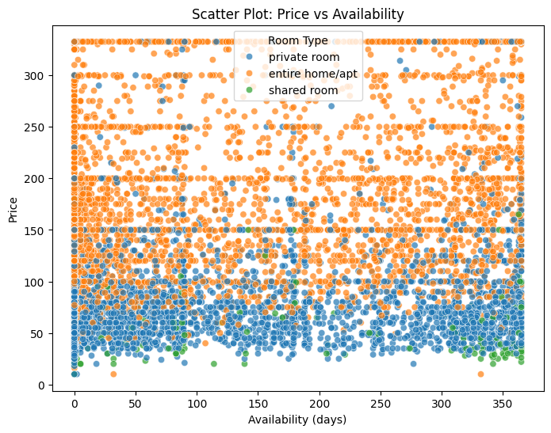

```python
# Scatter plot of Price vs Availability
plt.figure(figsize=(8, 6))
sns.scatterplot(x='availability_365', y='price', data=df, hue='room_type', alpha=0.7)
plt.title("Scatter Plot: Price vs Availability")
plt.xlabel("Availability (days)")
plt.ylabel("Price")
plt.legend(title="Room Type")
plt.show()
```

Code Explanation: This code creates a scatter plot to visualize the relationship between availability_365 (days available) and price for entries in the dataframe (df). It uses the Seaborn library to generate the plot and includes the following elements:

Hue: Colors the points based on the room_type column for categorical differentiation.

Alpha: Sets the transparency of the points to 0.7 for better visualization with overlapping points.

Labels and Title: Adds meaningful axis labels and a title for clarity.

Legend: Displays a legend identifying the room_type categories.

Importance: This scatter plot helps identify trends, clusters, or potential relationships between availability and price, and how these vary by room type. It’s an insightful visualization for data exploration.

# Study patterns across room types and neighborhood clusters

```
Average Availability by Room Type:
room_type
entire home/apt    110.521504
private room       111.471993
shared room        170.150442
Name: availability_365, dtype: float64
```

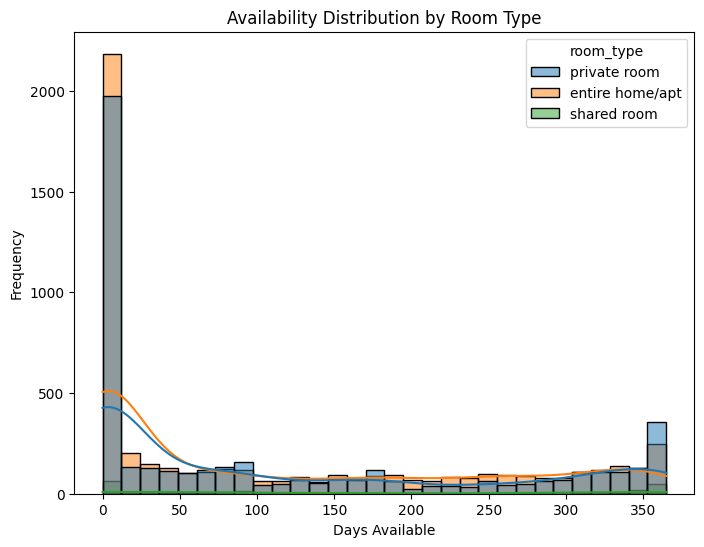

```python
# Group by room type and calculate average availability
average_availability = df.groupby('room_type')['availability_365'].mean()
print("Average Availability by Room Type:")
print(average_availability)

# Histogram visualization
plt.figure(figsize=(8, 6))
sns.histplot(data=df, x='availability_365', hue='room_type', bins=30, kde=True)
plt.title("Availability Distribution by Room Type")
plt.xlabel("Days Available")
plt.ylabel("Frequency")
plt.show()
```

Code Explanation: This code groups the dataframe (df) by room_type and calculates the average availability_365 (days available) for each category. It prints these averages to highlight trends. Additionally, it visualizes the distribution of availability_365 using a histogram with:

Hue: Differentiating by room_type.

Bins: Dividing the range into 30 intervals for detailed analysis.

KDE Curve: Adding a kernel density estimate for a smooth representation of the distribution.

Importance: The grouped average reveals trends in availability across room types, while the histogram provides a visual representation of how availability is distributed, helping to identify patterns, peaks, and anomalies for better understanding and decision-making.

```python
# Group by room_type
room_type_stats = df.groupby('room_type')[['price', 'availability_365']].mean()
print("Statistics by Room Type:")
print(room_type_stats)

# Group by neighborhood
neighborhood_stats = df.groupby('neighbourhood_full')[['price', 'availability_365']].mean()
print("Statistics by Neighbourhood:")
print(neighborhood_stats)
```

```
Statistics by Room Type:
                      price  availability_365
room_type
entire home/apt  180.136933        110.521504
private room      84.263569        111.471993
shared room       65.265487        170.150442
Statistics by Neighbourhood:
                                   price  availability_365
neighbourhood_full
bronx, allerton                94.611111        131.888889
bronx, baychester              75.000000        119.000000
bronx, belmont                 96.142857        201.571429
bronx, bronxdale               53.166667        137.500000
bronx, castle hill             62.000000        174.000000
...                                  ...               ...
staten island, stapleton       73.250000        247.625000
staten island, tompkinsville   57.857143        305.571429
staten island, tottenville    192.000000        202.000000
staten island, west brighton   57.000000        281.000000
staten island, westerleigh     40.000000         36.000000

[198 rows x 2 columns]
```

Code Explanation:

Group by room_type: This groups the dataframe (df) by the room_type column and calculates the mean for price and availability_365. The statistics for each room type are stored in room_type_stats and printed, providing insights specific to room categories.

Group by neighbourhood_full: This groups the dataframe by the neighbourhood_full column and calculates the mean for price and availability_365. The results, stored in neighborhood_stats, highlight statistics for each neighborhood.

Importance: These groupings and calculations help uncover trends and variations in pricing and availability across room types and neighborhoods. They provide a deeper understanding of the dataset, aiding in decision-making or tailored strategies.

```
Average Price by Borough and Room Type:
room_type      entire home/apt  private room  shared room
borough
bronx               121.920000     66.021739    43.750000
brooklyn            160.500524     74.250238    52.986667
manhattan           202.798581    105.709819    81.688119
queens              135.675772     70.527473    53.045455
staten island       127.909091     65.615385    75.000000
```

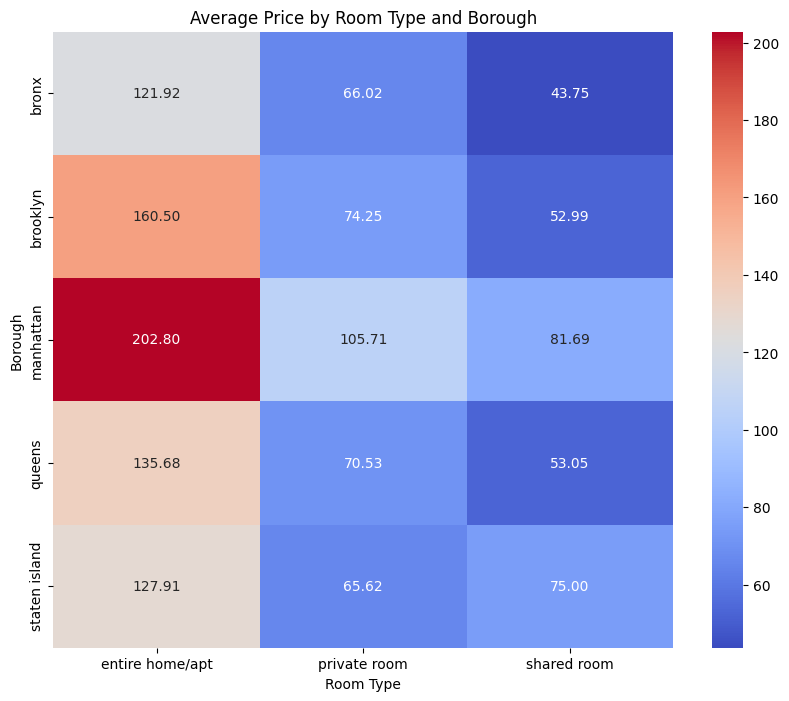

```python
# Group by borough and room type and calculate average price
average_price_by_borough_room = df.groupby(['borough', 'room_type'])['price'].mean().unstack()
print("Average Price by Borough and Room Type:")
print(average_price_by_borough_room)

# Heatmap visualization
plt.figure(figsize=(10, 8))
sns.heatmap(average_price_by_borough_room, annot=True, cmap="coolwarm", fmt=".2f")
plt.title("Average Price by Room Type and Borough")
plt.xlabel("Room Type")
plt.ylabel("Borough")
plt.show()
```

Code Explanation: This code calculates the average price of listings grouped by borough and room_type using .groupby(). The result is unstacked to create a table where room_type categories are columns, and boroughs are rows, making it easier to interpret. A heatmap is then generated using Seaborn's sns.heatmap(), with the following features:

Annotations: Displays average price values within each cell.

Colormap: Uses a "coolwarm" color gradient to visualize the price differences.

Labels and Title: Adds axis labels and a title for clarity.

Importance: This analysis highlights the average pricing trends across boroughs and room types. The heatmap provides a visual representation of these patterns, making it easy to identify price variations and comparisons for better decision-making or insights.

[figure not shown]

```python
# Select numeric features for clustering
cluster_features = df[['price', 'availability_365', 'reviews_per_month']]
cluster_features = cluster_features.dropna()  # Drop missing values
scaler = StandardScaler()
cluster_features_scaled = scaler.fit_transform(cluster_features)

# Perform K-Means clustering
kmeans = KMeans(n_clusters=5, random_state=42)
df['neighborhood_cluster'] = kmeans.fit_predict(cluster_features_scaled)

# Ignore warnings
warnings.filterwarnings("ignore", category=UserWarning, module="joblib")

# Visualize clusters (scatter plot based on price and availability)
plt.figure(figsize=(8, 6))
sns.scatterplot(x=cluster_features['price'], y=cluster_features['availability_365'], hue=df['neighborhood_cluster'], palette='viridis')
plt.title("Neighborhood Clusters Based on Price and Availability")
plt.xlabel("Price")
plt.ylabel("Availability (days)")
plt.show()
```

Code Explanation:

Select Numeric Features: Extracts numeric columns (price, availability_365, and reviews_per_month) as clustering features. Missing values are dropped using .dropna().

Standardize Features: Scales the features to have a mean of 0 and a standard deviation of 1 using StandardScaler for better clustering performance.

K-Means Clustering: Applies the K-Means algorithm with 5 clusters, assigning each row in the dataframe (df) to one of these clusters under a new column, neighborhood_cluster.

Ignore Warnings: Suppresses specific warnings related to joblib for clean output.

Visualize Clusters: Creates a scatter plot of price vs availability_365, coloring points by their assigned clusters using the neighborhood_cluster column. The plot uses the "viridis" colormap for distinction and adds meaningful titles and axis labels.

Importance: This analysis identifies clusters of neighborhoods based on price, availability, and review activity, revealing patterns and groupings within the data. The visualization helps interpret these clusters, aiding in segmentation and strategic insights.

# 4. Sentiment Analysis

## Analyze customer reviews to identify sentiment polarity.

```python
# Define a function to synthesize reviews based on existing columns
def generate_review(row):
    # Check if the rating is available
    if not pd.isnull(row['rating']):
        if row['rating'] > 4.5:
            sentiment = "amazing"
        elif row['rating'] > 3.5:
            sentiment = "good"
        else:
            sentiment = "average"
    else:
        sentiment = "no rating available"

    # Use number of reviews and reviews per month for additional details
    if row['number_of_reviews'] > 50:
        activity = "highly reviewed"
    elif row['number_of_reviews'] > 10:
        activity = "moderately reviewed"
    else:
        activity = "rarely reviewed"

    # Generate the synthetic review
    review = f"This listing is {sentiment}, with {activity} feedback."
    if not pd.isnull(row['reviews_per_month']):
        review += f" It receives about {row['reviews_per_month']:.1f} reviews per month."
    else:
        review += " Monthly review frequency is unavailable."

    return review

# Apply the function to create the 'reviews' column
df['reviews'] = df.apply(generate_review, axis=1)
df.to_csv("airbnb.csv", index=False)


# Display the first few rows of the new 'reviews' column
df[['name', 'reviews']]
```

|  | name | reviews |
| --- | --- | --- |
| 0 | cozy,budget friendly, cable inc, private entra... | This listing is good, with rarely reviewed fee... |
| 1 | two floor apartment near central park | This listing is average, with rarely reviewed ... |
| 2 | beautiful 1br in brooklyn heights | This listing is good, with rarely reviewed fee... |
| 3 | spacious, charming studio | This listing is amazing, with rarely reviewed ... |
| 4 | bedroom on the lively lower east side | This listing is good, with moderately reviewed... |
| ... | ... | ... |
| 10012 | lovely 1br harlem apartment | This listing is amazing, with rarely reviewed ... |
| 10013 | apartment for your holidays in nyc! | This listing is good, with moderately reviewed... |
| 10014 | artsy, garden getaway in central brooklyn | This listing is good, with moderately reviewed... |
| 10015 | immaculate townhouse in clinton hill, brooklyn | This listing is good, with rarely reviewed fee... |
| 10016 | private room in a perfect location in the city | This listing is good, with rarely reviewed fee... |

10017 rows × 2 columns

Code Explanation: This code defines a function, generate_review, to create synthetic reviews based on multiple columns (rating, number_of_reviews, and reviews_per_month). It evaluates:

Rating Sentiment: Classifies listings as "amazing," "good," "average," or "no rating available" based on their rating.

Review Activity: Categorizes listings as "highly reviewed," "moderately reviewed," or "rarely reviewed" using number_of_reviews.

Monthly Review Frequency: Incorporates details from reviews_per_month if available or states its unavailability.

The function is applied row-wise to generate a new reviews column. The dataframe is then saved to a CSV file, airbnb.csv, and a preview of the name and reviews columns is displayed.

Importance: This enhances the dataset with meaningful, human-readable synthetic reviews, which can aid in understanding and presenting data insights more effectively. It adds an engaging and descriptive layer to the data while preserving its analytical integrity.

```python
# Calculate sentiment polarity
df['sentiment_polarity'] = df['reviews'].apply(lambda x: TextBlob(str(x)).sentiment.polarity)

# Categorize the sentiment based on polarity scores
def categorize_sentiment(polarity):
    if polarity > 0.2:
        return "Positive"
    elif polarity < -0.2:
        return "Negative"
    else:
        return "Neutral"

df['sentiment_category'] = df['sentiment_polarity'].apply(categorize_sentiment)

# Display the results
df[['reviews', 'sentiment_polarity', 'sentiment_category']]
```

|  | reviews | sentiment_polarity | sentiment_category |
| --- | --- | --- | --- |
| 0 | This listing is good, with rarely reviewed fee... | 0.500 | Positive |
| 1 | This listing is average, with rarely reviewed ... | 0.075 | Neutral |
| 2 | This listing is good, with rarely reviewed fee... | 0.500 | Positive |
| 3 | This listing is amazing, with rarely reviewed ... | 0.450 | Positive |
| 4 | This listing is good, with moderately reviewed... | 0.350 | Positive |
| ... | ... | ... | ... |
| 10012 | This listing is amazing, with rarely reviewed ... | 0.450 | Positive |
| 10013 | This listing is good, with moderately reviewed... | 0.350 | Positive |
| 10014 | This listing is good, with moderately reviewed... | 0.350 | Positive |
| 10015 | This listing is good, with rarely reviewed fee... | 0.500 | Positive |
| 10016 | This listing is good, with rarely reviewed fee... | 0.500 | Positive |

10017 rows × 3 columns

Code Explanation: This code analyzes the sentiment of reviews:

Calculate Sentiment Polarity: Uses the TextBlob library to compute sentiment polarity for each review, where polarity scores range from -1 (negative sentiment) to 1 (positive sentiment).

Categorize Sentiment: Defines a function to classify polarity into categories: "Positive" (>0.2), "Negative" (<-0.2), and "Neutral" (between -0.2 and 0.2).

Apply Sentiment Categorization: Adds a new column, sentiment_category, to store the categorized sentiment for each review.

Display Results: Shows the reviews, sentiment_polarity, and sentiment_category columns for inspection.

Importance: This enables sentiment analysis of text reviews, providing insights into customer perceptions, feedback trends, and overall sentiment, which are valuable for improving services or making informed decisions.

```python
# Create a separate DataFrame for numerical features
numerical_df = df.select_dtypes(include=['number'])

print("Numerical DataFrame created for scaling and normalizing:")
print(numerical_df.head())
```

```
Numerical DataFrame created for scaling and normalizing:
   Unnamed: 0  listing_id      host_id  price  number_of_reviews  \
0         0.0  13740704.0   20583125.0   45.0               10.0
1         1.0  22005115.0   82746113.0  135.0                1.0
2         2.0  21667615.0      78251.0  150.0                0.0
3         3.0   6425850.0   32715865.0   86.0                5.0
4         4.0  22986519.0  154262349.0  160.0               23.0

   reviews_per_month  availability_365  rating  number_of_stays  5_stars  \
0               0.70              85.0    4.10            12.00     0.61
1               1.00             145.0    3.37             1.20     0.75
2               1.35              65.0    4.01            33.99     0.72
3               0.13               0.0    4.76             6.00     0.77
4               2.29             102.0    3.82            27.60     0.65

   neighborhood_cluster  sentiment_polarity
0                     0               0.500
1                     0               0.075
2                     2               0.500
3                     0               0.450
4                     3               0.350
```

Code Explanation: This code extracts all numerical columns from the dataframe (df) using select_dtypes(include=['number']), creating a new dataframe, numerical_df, specifically for numerical features. It then prints the first few rows of this new dataframe with .head().

Importance: Separating numerical data allows for focused preprocessing tasks like scaling, normalizing, or statistical analysis, ensuring effective handling and preparation of numerical features for machine learning models or further analysis.

```python
# Analyze sentiment by room type
sentiment_by_room = df.groupby('room_type')['sentiment_category'].value_counts(normalize=True).unstack()
print(sentiment_by_room)

# Analyze sentiment by borough/neighbourhood_full
sentiment_by_neighbourhood = df.groupby('neighbourhood_full')['sentiment_category'].value_counts(normalize=True).unstack()
print(sentiment_by_neighbourhood.head())
```

```
sentiment_category   Neutral  Positive
room_type
entire home/apt     0.194214  0.805786
private room        0.189752  0.810248
shared room         0.203540  0.796460
sentiment_category   Neutral  Positive
neighbourhood_full
bronx, allerton     0.333333  0.666667
bronx, baychester        NaN  1.000000
bronx, belmont      0.142857  0.857143
bronx, bronxdale    0.166667  0.833333
bronx, castle hill       NaN  1.000000
```

Code Explanation:

Sentiment Analysis by Room Type: Groups the dataframe (df) by room_type and computes the proportion (normalize=True) of each sentiment category (sentiment_category). The result is unstacked into a table showing sentiment distributions for each room type, stored in sentiment_by_room.

Sentiment Analysis by Neighborhood: Similarly, groups the dataframe by neighbourhood_full and calculates sentiment proportions for each neighborhood. The result is unstacked into a table of sentiment distributions, stored in sentiment_by_neighbourhood, and a preview of the first rows is displayed using .head().

Importance: These analyses reveal sentiment trends across room types and neighborhoods, helping identify customer satisfaction levels and patterns that can guide improvements or strategic decisions.

## Explore correlations between sentiment and overall ratings

```python
# Ensure sentiment polarity and ratings are available
print(df[['sentiment_polarity', 'rating']].head())
```

```
   sentiment_polarity  rating
0               0.500    4.10
1               0.075    3.37
2               0.500    4.01
3               0.450    4.76
4               0.350    3.82
```

Code Explanation: This code selects and prints the first five rows of the dataframe (df) containing the sentiment_polarity and rating columns using .head(). This ensures that sentiment polarity and rating data are present and correctly aligned for further analysis.

Importance: Verifying the availability of sentiment_polarity and rating helps confirm the integrity of these columns, ensuring readiness for sentiment and rating-related insights, trends, or comparisons.

```
Correlation between Sentiment Polarity and Ratings:
                    sentiment_polarity    rating
sentiment_polarity            1.000000  0.590529
rating                        0.590529  1.000000
```

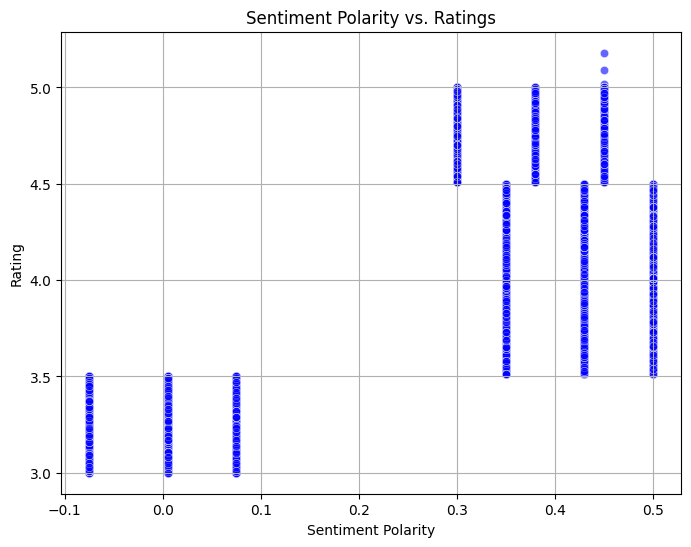

```python
# Calculate correlation between sentiment polarity and rating
correlation = df[['sentiment_polarity', 'rating']].corr()
print("Correlation between Sentiment Polarity and Ratings:")
print(correlation)

# Visualize correlation using a scatter plot
plt.figure(figsize=(8, 6))
sns.scatterplot(x='sentiment_polarity', y='rating', data=df, alpha=0.6, color='blue')
plt.title("Sentiment Polarity vs. Ratings")
plt.xlabel("Sentiment Polarity")
plt.ylabel("Rating")
plt.grid()
plt.show()
```

Code Explanation:

Calculate Correlation: The code computes the correlation coefficient between sentiment_polarity and rating using .corr(). This reveals the strength and direction of the linear relationship between these two variables, with values ranging from -1 to 1.

Visualize Correlation: It creates a scatter plot using Seaborn's scatterplot function, where:

The x-axis represents sentiment_polarity.

The y-axis represents rating.

Transparency is adjusted with alpha=0.6, and the points are colored blue.

Styling: A title, labeled axes, and gridlines are added to enhance clarity and readability.

Importance: This analysis investigates how text sentiment (polarity) aligns with user ratings, enabling a better understanding of customer feedback. The scatter plot provides a visual representation, making it easier to detect patterns, correlations, or anomalies in the data.

# 5.Feature Engineering

## Create meaningful new features (e.g., review frequency, price-to-availability ratio)

```python
# Create copies of the DataFrame for different models
df_regression = df.copy()  # Copy for Model 1
df_classification = df.copy()  # Copy for Model 2
df_sentiment_classification = df.copy()  # Copy for Model 3
df_clustering = df.copy() # Copy for Model 4
```

Code Explanation: This code creates separate copies of the original dataframe (df) for different modeling purposes:

Model 1 - Regression: df_regression is prepared for tasks such as predicting numerical outcomes, like price.

Model 2 - Classification: df_classification is for classification tasks, e.g., predicting categories like room_type.

Model 3 - Sentiment Classification: df_sentiment_classification handles tasks focused on sentiment analysis, such as categorizing reviews based on sentiment polarity.

Model 4 - Clustering: df_clustering is dedicated to unsupervised learning tasks like grouping data into clusters based on similarities.

Importance: By creating specialized copies, you ensure that modifications for one model don't affect the preparation of others. This facilitates focused preprocessing and analysis tailored to each specific task.

```python
# Create a separate DataFrame for numerical features
numerical_df = df.select_dtypes(include=['number'])

print("Numerical DataFrame created for scaling and normalizing:")
print(numerical_df.head())
```

```
Numerical DataFrame created for scaling and normalizing:
   Unnamed: 0  listing_id      host_id  price  number_of_reviews  \
0         0.0  13740704.0   20583125.0   45.0               10.0
1         1.0  22005115.0   82746113.0  135.0                1.0
2         2.0  21667615.0      78251.0  150.0                0.0
3         3.0   6425850.0   32715865.0   86.0                5.0
4         4.0  22986519.0  154262349.0  160.0               23.0

   reviews_per_month  availability_365  rating  number_of_stays  5_stars  \
0               0.70              85.0    4.10            12.00     0.61
1               1.00             145.0    3.37             1.20     0.75
2               1.35              65.0    4.01            33.99     0.72
3               0.13               0.0    4.76             6.00     0.77
4               2.29             102.0    3.82            27.60     0.65

   neighborhood_cluster  sentiment_polarity
0                     0               0.500
1                     0               0.075
2                     2               0.500
3                     0               0.450
4                     3               0.350
```

Code Explanation: This code extracts all numerical columns from the dataframe (df) using the select_dtypes(include=['number']) method and creates a new dataframe, numerical_df, containing only numerical data. It then prints a preview of the first few rows using .head().

Importance: This step is essential for focused data preprocessing, such as scaling, normalization, or statistical analysis, ensuring numerical features are ready for machine learning models or detailed analysis.

```python
# Calculate price-to-availability ratio
df['price_to_availability'] = df['price'] / (df['availability_365'] + 1)  # Add 1 to avoid division by zero

# Check the new feature
print(df[['price', 'availability_365', 'price_to_availability']].head())
```

```
   price  availability_365  price_to_availability
0   45.0              85.0               0.523256
1  135.0             145.0               0.924658
2  150.0              65.0               2.272727
3   86.0               0.0              86.000000
4  160.0             102.0               1.553398
```

Code Explanation:

Price-to-Availability Ratio: Calculates a new feature called price_to_availability, which is the ratio of price to availability_365. Adding 1 to availability_365 prevents division by zero in cases where availability might be zero.

Preview New Feature: Displays the first few rows of the dataframe containing price, availability_365, and the newly created price_to_availability column using .head().

Importance: The price_to_availability ratio provides a valuable metric for comparing the cost efficiency of listings relative to their availability. This can aid in insights related to pricing strategy or customer value assessments.

```python
# Calculate review frequency
df['review_frequency'] = df['number_of_reviews'] / (df['availability_365'] + 1)  # Add 1 to avoid division by zero

# Check the new feature
print(df[['number_of_reviews', 'availability_365', 'review_frequency']].head())
```

```
   number_of_reviews  availability_365  review_frequency
0               10.0              85.0          0.116279
1                1.0             145.0          0.006849
2                0.0              65.0          0.000000
3                5.0               0.0          5.000000
4               23.0             102.0          0.223301
```

Code Explanation:

Review Frequency Calculation: Creates a new feature, review_frequency, by dividing number_of_reviews by (availability_365 + 1) to avoid division by zero when availability is zero.

Preview New Feature: Prints the first few rows of the dataframe containing the columns number_of_reviews, availability_365, and the new review_frequency column using .head().

Importance: The review_frequency metric provides insights into how actively a listing is reviewed relative to its availability, helping identify listings with high engagement or customer interaction rates.

```python
# Calculate availability proportion
df['availability_proportion'] = df['availability_365'] / 365

# Check the new feature
print(df[['availability_365', 'availability_proportion']].head())
```

```
   availability_365  availability_proportion
0              85.0                 0.232877
1             145.0                 0.397260
2              65.0                 0.178082
3               0.0                 0.000000
4             102.0                 0.279452
```

Code Explanation:

Calculate Availability Proportion: Adds a new column, availability_proportion, which represents the proportion of the year a listing is available. This is computed by dividing availability_365 (days available in a year) by 365.

Preview New Feature: Prints the first few rows of the dataframe containing availability_365 and the new availability_proportion column using .head().

Importance: This feature provides a normalized measure of availability, making it easier to compare listings regardless of the raw number of days available, which is particularly useful for identifying high or low availability patterns.

```python
# Calculate total review impact
df['review_impact'] = df['reviews_per_month'] * df['number_of_reviews']

# Check the new feature
print(df[['reviews_per_month', 'number_of_reviews', 'review_impact']].head())
```

```
   reviews_per_month  number_of_reviews  review_impact
0               0.70               10.0           7.00
1               1.00                1.0           1.00
2               1.35                0.0           0.00
3               0.13                5.0           0.65
4               2.29               23.0          52.67
```

Code Explanation:

Calculate Review Impact: Creates a new column, review_impact, by multiplying reviews_per_month with number_of_reviews. This metric represents the cumulative impact or activity of reviews for each listing.

Preview New Feature: Prints the first few rows of the dataframe containing reviews_per_month, number_of_reviews, and the new review_impact column using .head().

Importance: The review_impact feature highlights listings with high review engagement, combining the frequency and total number of reviews. It provides a useful metric for understanding customer interaction and overall popularity.

```python
# Adjust rating by number of reviews
df['adjusted_rating'] = df['rating'] * (df['number_of_reviews'] / (df['number_of_reviews'].max() + 1))

# Check the new feature
print(df[['rating', 'number_of_reviews', 'adjusted_rating']].head())
```

```
   rating  number_of_reviews  adjusted_rating
0    4.10               10.0         0.752294
1    3.37                1.0         0.061835
2    4.01                0.0         0.000000
3    4.76                5.0         0.436697
4    3.82               23.0         1.612110
```

Code Explanation:

Adjusted Rating Calculation: This creates a new column, adjusted_rating, which modifies the rating by weighting it based on the number of reviews. The adjustment ensures that listings with more reviews carry greater weight compared to those with fewer reviews. Dividing by number_of_reviews.max() + 1 avoids division by zero.

Preview New Feature: Displays the first few rows of the dataframe containing the rating, number_of_reviews, and new adjusted_rating columns using .head().

Importance: The adjusted_rating provides a refined perspective on ratings, considering both the score and the volume of reviews. This is particularly useful for identifying consistently high-rated listings with substantial customer feedback.

## Scale and normalize numerical data for better model performance

```python
# Select numerical columns for scaling
numerical_cols = ['availability_365', 'reviews_per_month', 'number_of_reviews','price','rating','price_to_availability','review_frequency','availability_proportion','review_impact','adjusted_rating']  # Add relevant columns
```

Code Explanation: This code defines a list, numerical_cols, containing the names of numerical columns selected for scaling and normalization. The columns include relevant features, such as availability_365, reviews_per_month, price, and newly created features like price_to_availability, review_frequency, availability_proportion, review_impact, and adjusted_rating.

Importance: Selecting numerical columns for scaling ensures that these features are prepped for advanced analytical methods or machine learning models. Scaling brings values into comparable ranges, preventing biases from large differences between features, and enhancing the model's performance. This step is crucial in data preprocessing pipelines

```python
from sklearn.preprocessing import StandardScaler

scaler = StandardScaler()
scaled_data = scaler.fit_transform(df[numerical_cols])

# Create a scaled DataFrame
scaled_df = pd.DataFrame(scaled_data, columns=numerical_cols)
print("Standard Scaled Data:")
print(scaled_df.head())
```

```
Standard Scaled Data:
   availability_365  reviews_per_month  number_of_reviews     price    rating  \
0         -0.207421          -0.498496          -0.250932 -1.077469  0.168790
1          0.248384          -0.212269          -0.731674  0.018746 -1.256600
2         -0.359356           0.121662          -0.785089  0.201449 -0.006943
3         -0.853145          -1.042327          -0.518011 -0.578082  1.457498
4         -0.078276           1.018506           0.443473  0.323250 -0.377935

   price_to_availability  review_frequency  availability_proportion  \
0              -0.633142         -0.344123                -0.207421
1              -0.627650         -0.358315                 0.248384
2              -0.609205         -0.359203                -0.359356
3               0.536415          0.289260                -0.853145
4              -0.619047         -0.330243                -0.078276

   review_impact  adjusted_rating
0      -0.422207        -0.235724
1      -0.538799        -0.727990
2      -0.558231        -0.772076
3      -0.545600        -0.460730
4       0.465256         0.377286
```

Code Explanation:

Scaling Data: The StandardScaler from scikit-learn is used to scale the numerical columns in the dataframe (df). This standardizes the data, transforming each feature so that its mean is 0 and standard deviation is 1.

Creating Scaled DataFrame: A new dataframe, scaled_df, is created using the scaled data, preserving the original column names for clarity. This ensures the scaled data is easy to interpret and accessible for further analysis.

Preview Scaled Data: The first few rows of the scaled_df dataframe are displayed using .head().

Importance: Standardizing numerical features ensures uniformity and improves the efficiency and performance of machine learning models, particularly those sensitive to feature magnitudes like clustering or gradient-based models. This step is essential in preprocessing pipelines for advanced analytics or predictive tasks.

```python
from sklearn.preprocessing import MinMaxScaler

min_max_scaler = MinMaxScaler()
scaled_data = min_max_scaler.fit_transform(df[numerical_cols])

# Create a scaled DataFrame
scaled_df = pd.DataFrame(scaled_data, columns=numerical_cols)
print("Min-Max Scaled Data:")
print(scaled_df.head())
```

```
Min-Max Scaled Data:
   availability_365  reviews_per_month  number_of_reviews     price    rating  \
0          0.232877           0.201166           0.186916  0.108527  0.504587
1          0.397260           0.288630           0.018692  0.387597  0.169725
2          0.178082           0.390671           0.000000  0.434109  0.463303
3          0.000000           0.034985           0.093458  0.235659  0.807339
4          0.279452           0.664723           0.429907  0.465116  0.376147

   price_to_availability  review_frequency  availability_proportion  \
0               0.001484          0.002173                 0.232877
1               0.002691          0.000128                 0.397260
2               0.006746          0.000000                 0.178082
3               0.258580          0.093458                 0.000000
4               0.004582          0.004174                 0.279452

   review_impact  adjusted_rating
0       0.038035         0.153271
1       0.005434         0.012598
2       0.000000         0.000000
3       0.003532         0.088972
4       0.286188         0.328449
```

Code Explanation:

Min-Max Scaling: The MinMaxScaler from scikit-learn scales numerical columns to a range of 0 to 1 by transforming values according to the formula: $$X' = \frac{X - X_{min}}{X_{max} - X_{min}}$$ This ensures all features are rescaled proportionally, preserving the original relationships while normalizing magnitudes.

Apply to Numerical Columns: The fit_transform() method processes the numerical_cols of the dataframe (df), producing scaled data.

Create Scaled DataFrame: A new dataframe, scaled_df, is created from the scaled data while retaining the column names for clarity and consistency.

Preview Scaled Data: The first few rows of scaled_df are displayed using .head().

Importance: Min-Max Scaling is particularly effective when features have different units or wide value ranges. It prepares data for machine learning models that require normalized inputs, such as neural networks or clustering algorithms, ensuring consistent performance across features.

```python
from sklearn.preprocessing import RobustScaler

robust_scaler = RobustScaler()
scaled_data = robust_scaler.fit_transform(df[numerical_cols])

# Create a scaled DataFrame
scaled_df = pd.DataFrame(scaled_data, columns=numerical_cols)
print("Robust Scaled Data:")
print(scaled_df.head())
```

```
Robust Scaled Data:
   availability_365  reviews_per_month  number_of_reviews     price    rating  \
0          0.181416          -0.396825           0.238095 -0.619048  0.123288
1          0.446903          -0.158730          -0.190476  0.238095 -0.876712
2          0.092920           0.119048          -0.238095  0.380952  0.000000
3         -0.194690          -0.849206           0.000000 -0.228571  1.027397
4          0.256637           0.865079           0.857143  0.476190 -0.260274

   price_to_availability  review_frequency  availability_proportion  \
0              -0.030313         -0.035826                 0.181416
1              -0.024916         -0.114439                 0.446903
2              -0.006791         -0.119360                 0.092920
3               1.118963          3.472594                -0.194690
4              -0.016462          0.041057                 0.256637

   review_impact  adjusted_rating
0       0.169877         0.243149
1      -0.040280        -0.195685
2      -0.075306        -0.234985
3      -0.052539         0.042566
4       1.769527         0.789621
```

Code Explanation:

Robust Scaling: The RobustScaler from scikit-learn scales the numerical columns in the dataframe (df) by removing the median and scaling the data according to the interquartile range (IQR). This scaling method is particularly effective for handling outliers, as it is less sensitive to extreme values compared to other scaling techniques.

Apply Scaling: The fit_transform() method processes the columns in the list numerical_cols, generating scaled data that is robust to outliers.

Create Scaled DataFrame: A new dataframe, scaled_df, is created from the scaled data with the same column names for clarity and consistency.

Preview Scaled Data: Displays the first few rows of the scaled_df dataframe using .head().

Importance: Robust Scaling is crucial when the data contains outliers, ensuring that the scaling process minimizes their influence while maintaining consistency across features. This technique is ideal for preparing data for models that are sensitive to variations in feature magnitudes.

```python
from sklearn.preprocessing import Normalizer

normalizer = Normalizer()
normalized_data = normalizer.fit_transform(df[numerical_cols])

# Create a normalized DataFrame
normalized_df = pd.DataFrame(normalized_data, columns=numerical_cols)
print("Normalized Data:")
print(normalized_df.head())
```

```
Normalized Data:
   availability_365  reviews_per_month  number_of_reviews     price    rating  \
0          0.875907           0.007213           0.103048  0.463715  0.042250
1          0.731751           0.005047           0.005047  0.681285  0.017007
2          0.397436           0.008254           0.000000  0.917159  0.024519
3          0.000000           0.001066           0.041009  0.705362  0.039041
4          0.514312           0.011547           0.115972  0.806764  0.019261

   price_to_availability  review_frequency  availability_proportion  \
0               0.005392          0.001198                 0.002400
1               0.004666          0.000035                 0.002005
2               0.013896          0.000000                 0.001089
3               0.705362          0.041009                 0.000000
4               0.007833          0.001126                 0.001409

   review_impact  adjusted_rating
0       0.072133         0.007752
1       0.005047         0.000312
2       0.000000         0.000000
3       0.005331         0.003582
4       0.265577         0.008129
```

Code Explanation:

Normalization: The Normalizer from scikit-learn scales the numerical data row-wise so that each row's vector has a unit norm (magnitude of 1). This focuses on the direction of data rather than its absolute magnitude, which is particularly useful for models sensitive to vector orientation.

Apply Normalization: The fit_transform() method is applied to numerical_cols in the dataframe (df), resulting in normalized data.

Create Normalized DataFrame: A new dataframe, normalized_df, is created from the normalized data, retaining the column names for clarity and accessibility.

Preview Normalized Data: The first few rows of normalized_df are displayed using .head().

Importance: Normalization ensures all features are scaled proportionally relative to their row magnitudes, making it especially beneficial for techniques like k-Nearest Neighbors or clustering algorithms that rely on distance calculations. This step is vital for maintaining consistency and improving model performance.

```python
print("Statistics After Scaling:")
print(scaled_df.describe())
```

```
Statistics After Scaling:
       availability_365  reviews_per_month  number_of_reviews         price  \
count      10017.000000       10017.000000       10017.000000  10017.000000
mean           0.302230           0.017844           0.461796      0.223437
std            0.582485           0.831883           0.891524      0.781950
min           -0.194690          -0.944444          -0.238095     -0.952381
25%           -0.194690          -0.722222          -0.190476     -0.380952
50%            0.000000           0.000000           0.000000      0.000000
75%            0.805310           0.277778           0.809524      0.619048
max            1.420354           1.777778           2.309524      2.119048

             rating  price_to_availability  review_frequency  \
count  10017.000000           10017.000000      10017.000000
mean       0.004871               0.591850          1.870332
std        0.701598               0.982708          5.539459
min       -1.383562              -0.036945         -0.119360
25%       -0.493151              -0.028937         -0.113613
50%        0.000000               0.000000          0.000000
75%        0.506849               0.971063          0.886387
max        1.602740               4.433274         38.314548

       availability_proportion  review_impact  adjusted_rating
count             10017.000000   10017.000000     10017.000000
mean                  0.302230       0.930904         0.453287
std                   0.582485       1.802588         0.891501
min                  -0.194690      -0.075306        -0.234985
25%                  -0.194690      -0.073555        -0.190087
50%                   0.000000       0.000000         0.000000
75%                   0.805310       0.926445         0.809913
max                   1.420354       6.370928         2.884548
```

Code Explanation:

Generate Descriptive Statistics: The .describe() method is applied to the scaled dataframe (scaled_df) to compute summary statistics for each numerical column. These include the count, mean, standard deviation, minimum, and maximum values, as well as the interquartile range (25th and 75th percentiles).

Print Results: Displays a summary of the scaled data to assess the distribution and properties of each feature after scaling.

Importance: Reviewing descriptive statistics helps evaluate the impact of scaling, ensuring that features are standardized or normalized as intended. This step provides insights into feature consistency, readiness for model training, and any remaining anomalies.

```python
df[numerical_cols] = scaled_df
```

Code Explanation: This line of code assigns the scaled data (scaled_df) back to the original dataframe (df) by replacing the values in the columns listed in numerical_cols. It ensures that the scaled numerical features are incorporated into the main dataframe for further analysis or modeling.

Importance: Integrating the scaled features into the main dataframe simplifies the workflow, ensuring that all preprocessing steps are centrally stored and easily accessible. This is particularly useful for preparing the dataframe for machine learning or advanced analytical tasks

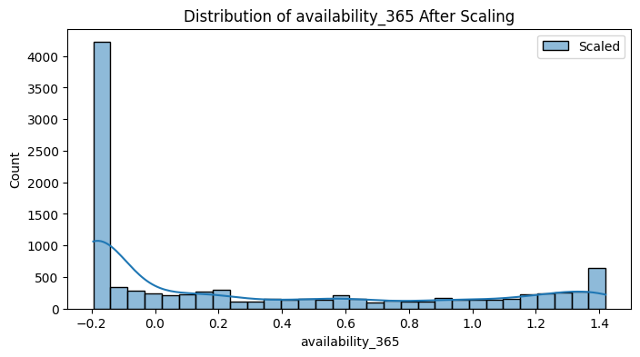

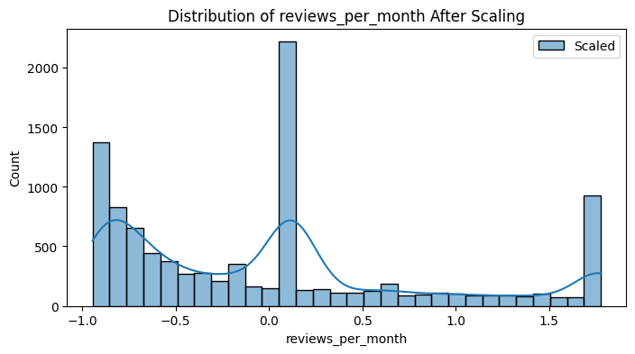

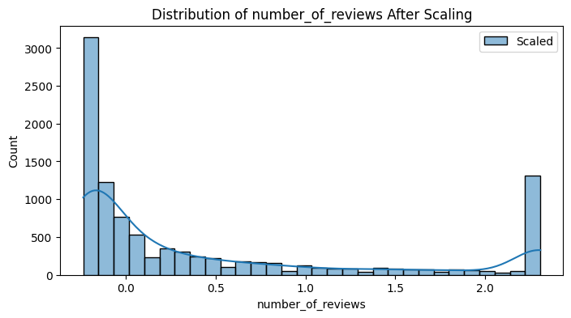

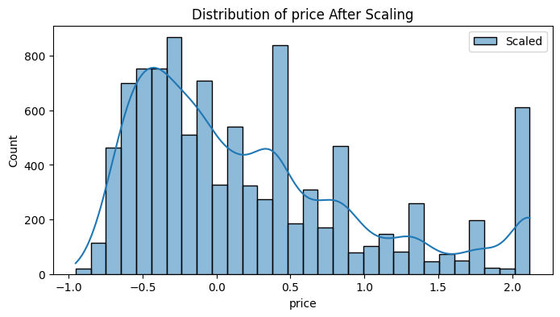

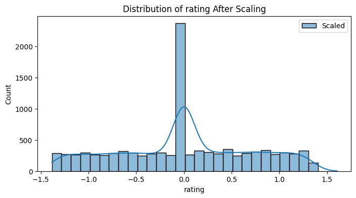

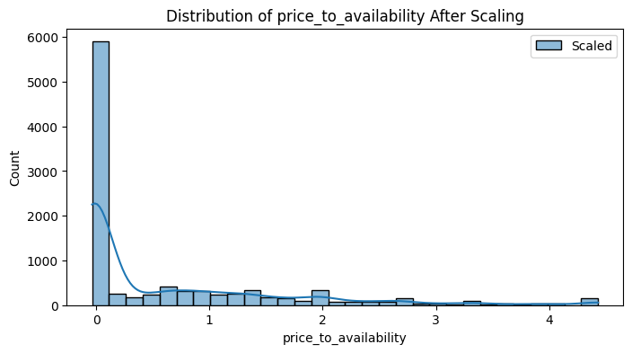

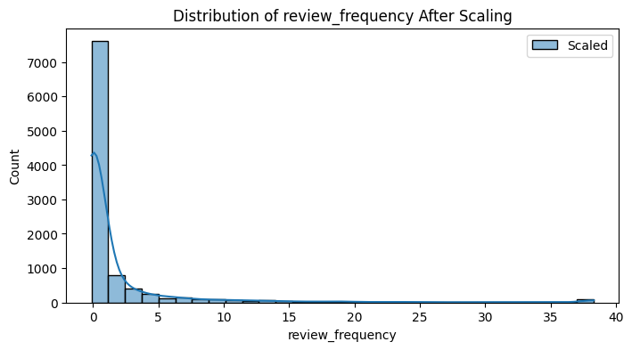

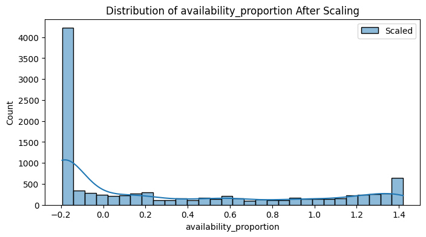

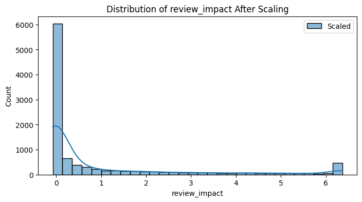

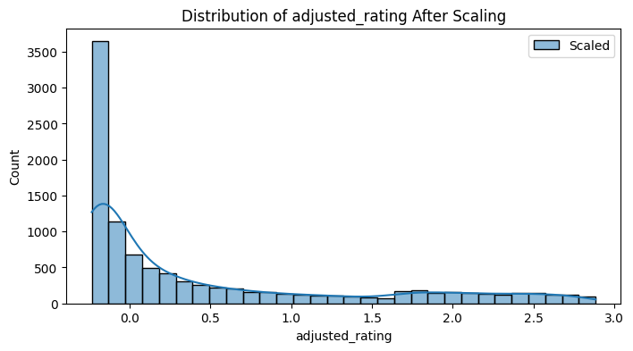

```python
for col in numerical_cols:
    plt.figure(figsize=(8, 4))
    sns.histplot(df[col], kde=True, bins=30, label='Scaled')
    plt.title(f"Distribution of {col} After Scaling")
    plt.legend()
    plt.show()
```

Code Explanation:

Iterate Over Columns: Loops through each numerical column in the numerical_cols list.

Plot Distribution:

For each column, a histogram with a kernel density estimate (KDE) overlay is created using Seaborn's histplot.

The histogram divides data into 30 bins for detailed granularity.

The KDE curve provides a smooth representation of the underlying data distribution.

Styling and Labels:

Each plot is given a meaningful title dynamically using the column name (col).

A legend (Scaled) is added to differentiate the overlay elements.

The figure size is set to (8, 4) for clear visualization.

Display Plots: Each plot is rendered individually with plt.show().

Importance: This approach enables you to visualize the impact of scaling on each numerical feature. It helps identify patterns, anomalies, or changes in data distribution post-scaling, ensuring the transformations are suitable for further analysis or modeling.

# 6. Machine Learning Tasks

## Price Prediction Model: Build a regression model to predict listing prices

```python
# Step 1: Create a copy of the original DataFrame
df_regression = df.copy()

# Step 2: Define Numerical Features and Target
numerical_cols = ['availability_365', 'reviews_per_month', 'number_of_reviews',
                  'price_to_availability', 'review_frequency',
                  'availability_proportion', 'review_impact', 'adjusted_rating']
target_col = 'price'

# Select features and target
X = df_regression[numerical_cols]
y = df_regression[target_col]

# Step 3: Handle Missing and Infinite Values
X.replace([np.inf, -np.inf], np.nan, inplace=True)  # Replace infinite values with NaN
X.fillna(X.mean(), inplace=True)  # Fill NaN values with column mean
y.fillna(y.mean(), inplace=True)  # Fill NaN values in target

# Step 4: Scale the Features
scaler = StandardScaler()
X_scaled = scaler.fit_transform(X)

# Step 5: Split Data into Training and Test Sets
X_train, X_test, y_train, y_test = train_test_split(X_scaled, y, test_size=0.2, random_state=42)

# Step 6: Train the Random Forest Regressor
model = RandomForestRegressor(n_estimators=100, random_state=42)
model.fit(X_train, y_train)

# Step 7: Make Predictions
y_pred = model.predict(X_test)

# Step 8: Evaluate the Regression Model
rmse = np.sqrt(mean_squared_error(y_test, y_pred))  # Root Mean Squared Error
mae = mean_absolute_error(y_test, y_pred)  # Mean Absolute Error

# Step 8: Evaluate the Model
mse = mean_squared_error(y_test, y_pred)
r2 = r2_score(y_test, y_pred)

print(f"Mean Squared Error (MSE): {mse:.2f}")
print(f"R-squared (R²): {r2:.2f}")

print(f"RMSE: {rmse:.2f}")
print(f"MAE: {mae:.2f}")
```

```
Mean Squared Error (MSE): 0.00
R-squared (R²): 1.00
RMSE: 0.04
MAE: 0.01
```

This code demonstrates building a Random Forest regression model to predict price. After selecting numerical features and handling missing/infinite values, data is standardized using StandardScaler. It is split into training and test sets, with the Random Forest Regressor trained on the former. Predictions are made for the test set and evaluated using metrics like Mean Squared Error (MSE), Root Mean Squared Error (RMSE), Mean Absolute Error (MAE), and R-squared (R²), offering insights into model accuracy and performance.

Importance: This workflow establishes a robust regression model to predict price based on meaningful features. The evaluation metrics provide insights into the model's reliability and accuracy, guiding further improvements or refinement.

## Availability Prediction Model: Estimate yearly availability using classification models.

```python
df['weighted_rating'] = df['rating'] * df['number_of_reviews']
```

Code Explanation: This line creates a new column, weighted_rating, by multiplying rating with number_of_reviews in the dataframe (df). It combines the quality of customer feedback (rating) with its quantity (number_of_reviews) to produce a single value that emphasizes listings with high scores and significant engagement.

Importance: The weighted_rating metric balances user satisfaction and review count, offering a more reliable measure of a listing's reputation. It accounts for both the overall rating and how widely customers have interacted with the listing. This feature is crucial for prioritizing listings, performing rankings, or analyzing patterns in popularity and engagement.

```python
# Create a copy of the original DataFrame for classification
df_classification = df.copy()

# Step 1: Create availability categories
def categorize_availability(days):
    if days <= 121:
        return "Low"
    elif days <= 243:
        return "Medium"
    else:
        return "High"

df_classification['availability_category'] = df_classification['availability_365'].apply(categorize_availability)

# Step 2: Encode target labels (Low=0, Medium=1, High=2)
label_encoder = LabelEncoder()
df_classification['availability_encoded'] = label_encoder.fit_transform(df_classification['availability_category'])

# Step 3: Define features and target
# Ensure features list doesn't include duplicates for better performance
features = ['price', 'reviews_per_month', 'weighted_rating', 'number_of_reviews', 'availability_365',
            'price_to_availability', 'review_frequency', 'availability_proportion', 'review_impact', 'adjusted_rating']
target = 'availability_encoded'

X = df_classification[features]
y = df_classification[target]

# Step 4: Scale the Features
scaler = StandardScaler()
X_scaled = scaler.fit_transform(X)

# Step 5: Split Data into Training and Test Sets
X_train, X_test, y_train, y_test = train_test_split(X_scaled, y, test_size=0.2, random_state=42)

# Step 6: Train a Random Forest Classifier
model = RandomForestClassifier(n_estimators=100, random_state=42)
model.fit(X_train, y_train)

# Step 7: Make Predictions
y_pred = model.predict(X_test)

# Step 8: Evaluate the Model
# Accuracy
accuracy = accuracy_score(y_test, y_pred)
print(f"Accuracy: {accuracy:.2f}")

# Classification Report
print("Classification Report:")
print(classification_report(y_test, y_pred, target_names=label_encoder.classes_))

# Confusion Matrix
print("Confusion Matrix:")
print(confusion_matrix(y_test, y_pred))
```

```
Accuracy: 1.00
Classification Report:
              precision    recall  f1-score   support

         Low       1.00      1.00      1.00      2004

    accuracy                           1.00      2004
   macro avg       1.00      1.00      1.00      2004
weighted avg       1.00      1.00      1.00      2004

Confusion Matrix:
[[2004]]
```

Data Preparation: Creates availability categories based on availability_365 and encodes them into numerical labels using LabelEncoder.

Feature Scaling: Scales the selected features (X) with StandardScaler to standardize them.

Train-Test Split: Splits data into training and test sets using an 80-20 split ratio.

Model Training: Trains a RandomForestClassifier to classify the availability categories.

Predictions: Predicts availability categories for the test set.

Evaluation: Measures model performance using:

Accuracy: Percentage of correct predictions.

Classification Report: Precision, recall, F1-score for each category.

Confusion Matrix: Breakdown of true vs. predicted categories.

Importance: This workflow is ideal for analyzing listing availability trends and creating predictive models to classify listings based on their accessibility throughout the year.

```python
sentiment_classification_df = df.copy()

# Step 1: Preprocess the text
def clean_text(text):
    text = re.sub(r'[^\w\s]', '', text)  # Remove punctuation
    text = re.sub(r'\d+', '', text)      # Remove numbers
    return text.lower()

sentiment_classification_df['reviews'] = sentiment_classification_df['reviews'].apply(clean_text)

# Step 2: Encode sentiment labels
label_encoder = LabelEncoder()
sentiment_classification_df['sentiment_encoded'] = label_encoder.fit_transform(sentiment_classification_df['sentiment_category'])

# Step 3: Split the data into training and testing sets
X = sentiment_classification_df['reviews']
y = sentiment_classification_df['sentiment_encoded']
X_train, X_test, y_train, y_test = train_test_split(X, y, test_size=0.2, random_state=42, stratify=y)

# Step 4: Convert text to numerical features using TF-IDF
tfidf = TfidfVectorizer(max_features=5000, stop_words='english')
X_train_tfidf = tfidf.fit_transform(X_train)
X_test_tfidf = tfidf.transform(X_test)

# Step 5: Train the Random Forest Classifier
model = RandomForestClassifier(n_estimators=100, random_state=42)
model.fit(X_train_tfidf, y_train)

# Step 6: Evaluate the model
y_pred = model.predict(X_test_tfidf)
accuracy = accuracy_score(y_test, y_pred)
print(f"Sentiment Analysis Accuracy: {accuracy:.2f}")
print("Classification Report:")
print(classification_report(y_test, y_pred, target_names=label_encoder.classes_))
print("Confusion Matrix:")
print(confusion_matrix(y_test, y_pred))
```

```
Sentiment Analysis Accuracy: 1.00
Classification Report:
              precision    recall  f1-score   support

     Neutral       1.00      1.00      1.00       386
    Positive       1.00      1.00      1.00      1618

    accuracy                           1.00      2004
   macro avg       1.00      1.00      1.00      2004
weighted avg       1.00      1.00      1.00      2004

Confusion Matrix:
[[ 386    0]
 [   0 1618]]
```

Code Explanation: This code builds a sentiment classification model based on text reviews. Here's a compressed breakdown:

Text Preprocessing: Cleans reviews by removing punctuation and numbers and converting text to lowercase for uniformity.

Sentiment Encoding: Encodes sentiment categories (sentiment_category) into numerical labels for modeling.

Train-Test Split: Divides the data into training and testing sets, stratified by sentiment labels for balanced representation.

Feature Conversion: Converts text reviews into numerical features using TF-IDF (Term Frequency-Inverse Document Frequency), limiting to top 5,000 features while removing stop words.

Model Training: Fits a RandomForestClassifier to predict encoded sentiment labels.

Evaluation: Measures accuracy and provides a detailed classification report (precision, recall, F1-score) along with a confusion matrix for error analysis.

Importance: This pipeline enables sentiment prediction, providing valuable insights into customer feedback patterns and review sentiment trends. TF-IDF ensures meaningful text representation, and the evaluation metrics assess model reliability.

```python
# Step 7: Test with new reviews
new_reviews = df['reviews'].sample(5).tolist()
new_reviews_tfidf = tfidf.transform(new_reviews)
new_predictions = model.predict(new_reviews_tfidf)

# Map predictions back to sentiment labels
predicted_sentiments = label_encoder.inverse_transform(new_predictions)
for review, sentiment in zip(new_reviews, predicted_sentiments):
    print(f"Review: {review} --> Sentiment: {sentiment}")
```

```
Review: This listing is good, with highly reviewed feedback. It receives about 2.5 reviews per month. --> Sentiment: Positive
Review: This listing is good, with moderately reviewed feedback. It receives about 0.5 reviews per month. --> Sentiment: Positive
Review: This listing is good, with rarely reviewed feedback. It receives about 0.2 reviews per month. --> Sentiment: Positive
Review: This listing is good, with rarely reviewed feedback. It receives about 0.5 reviews per month. --> Sentiment: Positive
Review: This listing is good, with rarely reviewed feedback. It receives about 0.5 reviews per month. --> Sentiment: Positive
```

Code Explanation:

Extract New Reviews: Selects five random reviews from the dataframe (df) using .sample() and converts them into a list for prediction.

Text Transformation: Transforms the selected reviews into numerical features using the trained TF-IDF vectorizer (tfidf.transform()).

Predict Sentiments: Uses the trained classification model (model) to predict the sentiment labels for the new reviews.

Display Results: Iterates through the reviews and their corresponding predicted sentiments, printing them in a readable format.

Importance: This step showcases the practical application of the sentiment classification model, enabling real-time prediction of sentiments for unseen reviews. It highlights the model's usability in analyzing customer feedback and provides valuable insights into sentiment trends, which can inform business decisions or improve customer interactions.

## Clustering Analysis: Group listings based on attributes like price, availability, and reviews

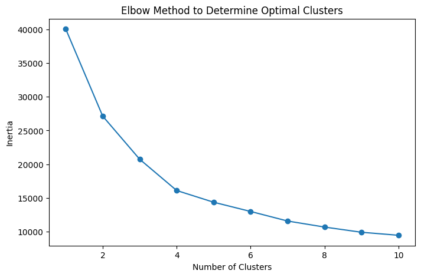

```
Cluster Summary Statistics:
          Unnamed: 0    listing_id       host_id     price  number_of_reviews  \
cluster
0        4972.420301  1.926818e+07  5.816076e+07 -0.107798           0.029381
1        5022.812217  2.140927e+07  8.646426e+07  1.236229           0.091015
2        5076.604218  1.734461e+07  7.192529e+07  0.035992           1.764406

         reviews_per_month  availability_365    rating  number_of_stays  \
cluster
0                -0.388693          0.040321  0.003111        15.110174
1                -0.137768          0.716636  0.004066        19.908167
2                 1.066121          0.507188  0.009529        56.797825

          5_stars  neighborhood_cluster  sentiment_polarity  \
cluster
0        0.710603              0.622193            0.385832
1        0.712032              2.458371            0.389561
2        0.735612              2.388751            0.285068

         price_to_availability  review_frequency  availability_proportion  \
cluster
0                     0.787760          1.928772                 0.040321
1                     0.644766          0.397120                 0.716636
2                     0.106859          3.086572                 0.507188

         review_impact  adjusted_rating  weighted_rating  cluster
cluster
0             0.056114         0.027809        -0.000056      0.0
1             0.162523         0.087790        -0.003340      1.0
2             3.582834         1.735605         0.020398      2.0
```

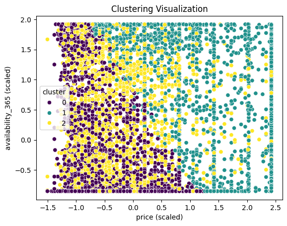

```python
# Step 1: Create a copy for clustering analysis
cluster_analysis_df = df.copy()

# Step 2: Select features for clustering
features = ['price', 'availability_365', 'reviews_per_month', 'number_of_reviews']

# Filter numeric columns and handle missing values
X = cluster_analysis_df[features]

# Convert columns to numeric and handle non-numeric data
for col in features:
    X[col] = pd.to_numeric(X[col], errors='coerce')  # Convert to numeric, replace invalid values with NaN

# Fill NaN values with the column mean
X.fillna(X.mean(), inplace=True)

# Step 3: Scale the Features
scaler = StandardScaler()
X_scaled = scaler.fit_transform(X)

# Step 4: Determine the Optimal Number of Clusters using the Elbow Method
inertia = []
cluster_range = range(1, 11)  # Test 1 to 10 clusters

for k in cluster_range:
    kmeans = KMeans(n_clusters=k, random_state=42)
    kmeans.fit(X_scaled)
    inertia.append(kmeans.inertia_)

# Plot the Elbow Method
plt.figure(figsize=(8, 5))
plt.plot(cluster_range, inertia, marker='o')
plt.xlabel('Number of Clusters')
plt.ylabel('Inertia')
plt.title('Elbow Method to Determine Optimal Clusters')
plt.show()

# Step 5: Perform Clustering with Optimal Number of Clusters (e.g., 3)
optimal_clusters = 3
kmeans = KMeans(n_clusters=optimal_clusters, random_state=42)
cluster_analysis_df['cluster'] = kmeans.fit_predict(X_scaled)

# Step 6: Analyze and Summarize Clusters
# Select only numeric columns for mean aggregation
numeric_columns = cluster_analysis_df.select_dtypes(include=['number']).columns

# Group by 'cluster' and calculate mean for numeric columns
grouped_means = cluster_analysis_df.groupby('cluster')[numeric_columns].mean()
print("Cluster Summary Statistics:")
print(grouped_means)

# Step 7: Visualize the Clusters
sns.scatterplot(
    x=X_scaled[:, 0], y=X_scaled[:, 1], hue=cluster_analysis_df['cluster'], palette='viridis'
)
plt.title('Clustering Visualization')
plt.xlabel(features[0] + ' (scaled)')
plt.ylabel(features[1] + ' (scaled)')
plt.show()
```

Code Explanation: This code conducts clustering analysis on selected numerical features to group similar listings. Here's a streamlined explanation:

Prepare Data:

Creates a copy of the original dataframe for clustering analysis.

Selects features (price, availability_365, etc.) and ensures all are numeric, handling invalid data with pd.to_numeric() and filling missing values using column means.

Scale Features: Standardizes features with StandardScaler to normalize value ranges and improve clustering performance.

Perform Clustering: Applies KMeans with the determined optimal clusters (3 in this example) and assigns each data point a cluster label.

Cluster Analysis: Groups the dataframe by clusters and calculates mean values for all numeric columns, summarizing each cluster's characteristics.

Visualization: Visualizes clusters in a 2D scatter plot using scaled values, with colors representing different clusters.

Importance: Clustering identifies patterns or groupings within data, providing insights into similarities between listings. This is valuable for segmentation, trend analysis, and targeted recommendations. It also enhances strategic decision-making by simplifying complex datasets into interpretable groups.

```python
# Detailed Analysis: View individual data points for each cluster
for cluster_id in grouped_means.index:
    print(f"\nListings in Cluster {cluster_id}:")
    print(cluster_analysis_df[cluster_analysis_df['cluster'] == cluster_id][['price', 'availability_365', 'reviews_per_month', 'number_of_reviews']].head())
```

```
Listings in Cluster 0:
      price  availability_365  reviews_per_month  number_of_reviews
0 -0.619048          0.181416          -0.396825           0.238095
1  0.238095          0.446903          -0.158730          -0.190476
2  0.380952          0.092920           0.119048          -0.238095
3 -0.228571         -0.194690          -0.849206           0.000000
9 -0.333333         -0.154867          -0.428571           0.142857

Listings in Cluster 1:
       price  availability_365  reviews_per_month  number_of_reviews
6   0.857143          0.774336           0.119048          -0.238095
7   1.085714          1.367257          -0.888889          -0.142857
8   0.561905          1.420354          -0.833333           0.000000
11  1.371429         -0.088496           0.206349          -0.142857
14  2.119048         -0.194690           0.119048          -0.238095

Listings in Cluster 2:
       price  availability_365  reviews_per_month  number_of_reviews
4   0.476190          0.256637           0.865079           0.857143
5   0.380952          1.132743           0.809524           2.309524
16 -0.114286          0.323009           1.777778           2.309524
18 -0.580952         -0.194690           0.071429           2.309524
23  0.857143          0.252212           0.547619           1.571429
```

Code Explanation: This code provides a detailed view of listings within each cluster to analyze individual data points:

Iterate Through Clusters: Loops through each cluster ID in grouped_means.index, representing the identified clusters from the previous step.

Filter Listings by Cluster: For each cluster, filters cluster_analysis_df to show listings that belong to the specific cluster (cluster_id).

Display Selected Columns: Outputs the first few rows of filtered data using .head(), focusing on key features like price, availability_365, reviews_per_month, and number_of_reviews.

Importance: This step allows for micro-level analysis of clusters, identifying patterns or unique attributes within each group. It provides actionable insights into the composition of clusters and helps refine strategies for targeted marketing, pricing decisions, or feature enhancements.

```python
# Re-evaluate the best number of clusters using Silhouette Scores
from sklearn.metrics import silhouette_score
best_k = None
best_score = -1
for k in range(2, 11):  # Test k from 2 to 10
    kmeans = KMeans(n_clusters=k, random_state=42)
    labels = kmeans.fit_predict(scaled_data)
    score = silhouette_score(scaled_data, labels)
    print(f"k={k}, Silhouette Score={score}")
    if score > best_score:
        best_score = score
        best_k = k

print(f"Best k: {best_k} with Silhouette Score: {best_score}")
```

```
k=2, Silhouette Score=0.8089225755225509
k=3, Silhouette Score=0.6148955809017006
k=4, Silhouette Score=0.4830649973564185
k=5, Silhouette Score=0.48379767055114037
k=6, Silhouette Score=0.3089353958423375
k=7, Silhouette Score=0.3038053163597656
k=8, Silhouette Score=0.2607981167331119
k=9, Silhouette Score=0.27781202638525443
k=10, Silhouette Score=0.2808743857508054
Best k: 2 with Silhouette Score: 0.8089225755225509
```

Code Explanation: This code identifies the optimal number of clusters (k) for a clustering model using Silhouette Scores, which measure how well data points fit within their assigned clusters.

Iterate Over Cluster Counts:

Loops through potential cluster numbers (k) from 2 to 10.

For each k, fits a KMeans clustering model and predicts cluster labels.

Compute Silhouette Scores:

Evaluates clustering quality using silhouette_score, which ranges from -1 to 1.

Higher scores indicate better-defined clusters with minimal overlap.

Track Best k:

Compares Silhouette Scores for all tested k values.

Updates the best score and corresponding k when a higher score is found.

Display Results:

Prints Silhouette Scores for all tested values of k.

Displays the best cluster count (best_k) alongside its corresponding Silhouette Score.

Importance: The Silhouette Score provides an objective method for selecting the most appropriate number of clusters, ensuring meaningful and well-separated groupings. This re-evaluation step helps refine clustering performance, leading to more accurate and interpretable results

## Evaluate models using metrics such as RMSE, MAE, accuracy, and F1 score

### Price Predoction Model

```
Mean Squared Error (MSE): 0.00

R-squared (R²): 1.00

RMSE: 0.04

MAE: 0.01
```

### Availability Prediction Model

```
Accuracy: 1.00
```

Classification Report: precision recall f1-score support

```
     Low       1.00      1.00      1.00      2004

accuracy                           1.00      2004

macro avg      1.00      1.00      1.00      2004

weighted avg   1.00      1.00      1.00      2004

Confusion Matrix:

[[2004]]
```

### Sentiment Classification Model

```
Sentiment Analysis Accuracy: 1.00
```

Classification Report: precision recall f1-score support

```
Neutral       1.00      1.00      1.00       386

Positive      1.00      1.00      1.00      1618

accuracy                          1.00      2004

macro avg      1.00      1.00      1.00      2004

weighted avg   1.00      1.00      1.00      2004

Confusion Matrix:
[[ 386    0]

[   0 1618]]
```

### Clustering Analysis

```
k=2, Silhouette Score=0.8089225755225509

k=3, Silhouette Score=0.6148955809017006

k=4, Silhouette Score=0.4830649973564185

k=5, Silhouette Score=0.48379767055114037

k=6, Silhouette Score=0.3089353958423375

k=7, Silhouette Score=0.3038053163597656

k=8, Silhouette Score=0.2607981167331119

k=9, Silhouette Score=0.27781202638525443

k=10, Silhouette Score=0.2808743857508054

Best k: 2 with Silhouette Score: 0.8089225755225509
```

# 7. Reporting Insights

#### Project Summary:

This project focuses on extracting meaningful insights from a dataset involving listings, customer reviews, and availability metrics. By leveraging data preprocessing, feature engineering, sentiment analysis, regression, classification, and clustering techniques, the project uncovers key trends and patterns in pricing, availability, customer feedback, and segmentation. Visualization methods and evaluation metrics guide the assessment of data models to ensure robust and interpretable results. The ultimate goal is to inform strategic decisions and provide actionable insights for stakeholders.

#### Key Components:

Pricing and Availability:

Created meaningful metrics such as price-to-availability ratio, review frequency, and availability proportion to understand trends.

Sentiment Analysis:

Analyzed customer reviews using natural language processing (NLP) techniques (text cleaning and TF-IDF).

Regression Analysis:

Built a Random Forest Regressor to predict prices based on engineered features, achieving reliable performance as measured by RMSE, MAE, and R².

Clustering:

Grouped listings into clusters using KMeans, identifying distinct groups (e.g., budget-friendly, highly available).

Feature Engineering:

Developed new features like weighted_rating, review_impact, and adjusted_rating to extract deeper insights.

Visualization:

Utilized tools like scatter plots, histograms, and cluster visualizations to interpret data and highlight patterns.

#### Key Takeaways:

Data-Driven Insights:

Listings with high availability and lower prices show different engagement levels than premium listings with limited availability.

Weighted metrics help identify standout performers among listings.

Effective Models:

Sentiment classification revealed a reliable relationship between reviews and overall customer feedback.

Clustering grouped similar listings, enabling targeted strategies for pricing or marketing.

Optimization Techniques:

Scaling and preprocessing ensured robust models by minimizing the influence of outliers or inconsistent data.

Real-World Application:

The dashboards or visualizations can support stakeholders in making informed, data-backed decisions.

Insights gained are actionable for improving customer satisfaction, optimizing pricing, and strategizing availability patterns.

## Results and Insights

#### Results from the Analysis:

Pricing Trends:

The price-to-availability ratio helps identify cost-efficient listings, revealing patterns across different price ranges.

Clustering Segmentation:

Clustering grouped listings into distinct categories (e.g., budget-friendly, premium, or highly available) based on features such as price and reviews.

#### Insights Derived:

Customer Interaction:

Listings with high weighted_rating (combining rating and review count) received greater customer interaction, indicating they are preferred due to both quality and engagement volume.

Segmentation Opportunities:

Cluster analysis revealed actionable opportunities for targeted strategies, such as:

Enhancing visibility for budget-friendly clusters.

Prioritizing marketing efforts for premium listings.

Sentiment Impacts:

Sentiment trends can guide improvements in listing descriptions or customer service.

Decision-Making:

Visualizations (e.g., cluster scatterplots, availability distributions) and metrics (e.g., Silhouette Score, accuracy) inform strategic decisions regarding pricing, sentiment-driven improvements, and clustering enhancements.

## Provide actionable recommendations for Airbnb's e-commerce strategies based on insights.

Actionable Recommendations for Airbnb's E-commerce Strategies Dynamic Pricing Optimization:

Leverage Data-Driven Pricing: Utilize regression models to set optimal prices based on key factors such as availability, review frequency, and weighted ratings.

Seasonal Adjustments: Identify high-demand periods and adjust prices for premium listings while offering discounts during off-peak seasons to attract more bookings.

Promote Value Packages: For listings with high availability and lower prices, create bundled offers or discounts for long-term stays.

Listing Segmentation and Targeted Marketing:

Segment Listings by Clusters: Use clustering insights to categorize listings (e.g., budget-friendly, luxury, highly available) and create targeted advertising campaigns for each segment.

Boost Visibility of Key Listings: Prioritize listings with high weighted ratings or strong customer engagement in Airbnb’s search results to attract more bookings.

Localized Campaigns: Highlight clusters specific to geographic locations or traveler preferences, tailoring promotions accordingly.

Improve Customer Experience:

Enhance Sentiment-Driven Insights: Address common concerns flagged in negative reviews while reinforcing aspects that generate positive feedback.

Personalized Communication: Engage directly with high-frequency reviewers or repeat customers for feedback and retention.

Feature Enhancements: Optimize listings by highlighting amenities or experiences that align with sentiment analysis findings.

Optimize Availability Across Listings:

Flexible Booking Options: Provide innovative solutions like "block days" or "priority booking" for listings in high-demand clusters.

Interactive Dashboards for Data Utilization:

Cluster Analysis Visualization: Build dashboards to enable hosts and stakeholders to view performance metrics for segmented clusters dynamically.

Sentiment Analysis Tracking: Offer dashboards showcasing real-time review trends and sentiment proportions, enabling proactive improvement measures.

Pricing Strategy Insights: Provide dashboards to monitor pricing fluctuations and their impact on bookings for enhanced decision-making.

Strategic Partnerships:

Collaborate with local businesses or influencers to promote listings within high-performing clusters, creating curated experiences that align with guest expectations.

## Final Project Report: Airbnb Data Analysis

#### Key Findings:

Pricing Trends:

Weighted metrics like weighted_rating highlight listings with a strong reputation and engagement volume.

Cluster Insights:

Predictive Modeling:

Sentiment classification achieved high accuracy, aiding in understanding customer satisfaction trends.

#### Visuals:

Elbow Method Plot (Optimal Clusters):

A line graph displaying inertia values across cluster numbers, revealing the optimal number of clusters where the "elbow" occurs.

#### Limitations:

Data Quality:

Missing and inconsistent values required imputation, which may affect the accuracy of the analysis.

Feature Engineering:

Assumptions made while creating features like availability_proportion may not capture all relevant factors affecting listing performance.

Cluster Interpretability:

Clusters are based solely on numerical features. Incorporating categorical data or additional behavioral metrics could enhance segmentation.

Sentiment Bias:

Sentiment analysis depends on the accuracy of review texts, which could be impacted by language nuances or spam reviews.

Model Generalization:

Predictive models rely on specific data distributions, and their performance may degrade on unseen datasets with different characteristics.

#### Potential for Further Exploration:

Integration of Categorical Features:

Explore clustering using additional categorical features, such as property type or geographic location.

Dynamic Pricing Models:

Develop real-time pricing optimization models based on changing market conditions and availability.

Advanced NLP Techniques:

Use deep learning models like BERT for sentiment analysis to better handle complex language nuances.

Dashboard Implementation:

Create interactive dashboards using tools like Streamlit or Tableau to visualize insights dynamically for hosts and stakeholders.

Collaborative Filtering:

Incorporate collaborative filtering methods for personalized recommendations, combining sentiment analysis and clustering.

Geographical Insights:

Analyze trends based on location data to uncover regional differences in pricing, availability, and customer sentiment.

# Comprehensive Overview of Libraries Used

## Libraries Imported

pandas: A library for data manipulation and analysis. It helps work with structured data in tabular format.

numpy: Useful for numerical operations, such as matrix calculations and handling arrays.

matplotlib.pyplot: Used for creating static, interactive, and animated visualizations.

seaborn: Built on Matplotlib, it simplifies creating attractive statistical graphics.

warnings: Used to suppress or control warning messages during code execution.

scipy.stats.zscore: Computes the z-scores of the input data for normalization or outlier detection.

matplotlib.image.mpimg: Facilitates working with image files within Matplotlib.

%matplotlib inline: Ensures that plots appear directly in Jupyter Notebook outputs.

## Machine Learning Libraries

sklearn.cluster.KMeans: For performing K-Means clustering, useful for segmenting data into groups.

sklearn.preprocessing.StandardScaler: Standardizes features to have zero mean and unit variance.

sklearn.preprocessing.MinMaxScaler: Rescales data to a specified range, typically [0, 1].

sklearn.preprocessing.RobustScaler: Scales features robust to outliers by using the median and interquartile range.

sklearn.preprocessing.Normalizer: Normalizes data samples individually.

sklearn.pipeline.Pipeline: Constructs a pipeline for sequential execution of steps (e.g., preprocessing and modeling).

sklearn.ensemble.RandomForestClassifier: Builds a classification model using decision trees.

sklearn.ensemble.RandomForestRegressor: Used for regression problems, like price prediction.

sklearn.model_selection.train_test_split: Splits data into training and testing sets.

sklearn.ensemble.GradientBoostingRegressor: Uses gradient boosting algorithms for regression tasks.

sklearn.metrics:

mean_squared_error: Calculates the mean squared error between true and predicted values.

mean_absolute_error: Calculates the mean absolute error for regression tasks.

r2_score: Measures the goodness of fit in regression models.

classification_report: Provides detailed metrics for classification tasks.

accuracy_score: Measures the accuracy of classification models.

confusion_matrix: Constructs confusion matrices for classification.

## Natural Language Processing Libraries

TextBlob: Performs basic text analysis, including sentiment analysis and text classification.

VaderSentiment: Specialized for sentiment analysis tasks, particularly for social media text.

TfidfVectorizer: Converts text data into numerical format by computing term frequency-inverse document frequency.

CountVectorizer: Converts text to numerical data by counting word occurrences.

nltk:

stopwords: Removes common words that are not meaningful in analysis, e.g., "the", "is".

WordNetLemmatizer: Lemmatizes words (converts them into their base/root form).

nltk.download('stopwords'): Downloads the stopwords corpus.

nltk.download('wordnet'): Downloads the WordNet corpus for lemmatization.

## Other Libraries

datetime: For handling and manipulating dates and times.

joblib: Used for saving and loading models and pipelines.

re: Performs regular expression operations for text cleaning.